# OMG finally the analyses

2026-05-27

We will finally analyse this data properly, and bring all datasets together… But there’s been changes to figures! So we gotta get creative.

## We need to clean up a bit for the new files, and define color scales:

I looked at the GWAS Catalog’s description of their ancestry curation, and I still don’t know what to do with the samples that Amanda has, because I would argue that this is genetic ancestry, poorly described, which is not necessarily the case for the other two datasets. But it also has a bunch of terms that are clearly racial in origin and inspiration, so, like… dunno what to do here.

```r
unique(dbGapFinal$variable) # This is really a horrible mix of both, but I guess primarily of geography terms, so I'm making it a new colour scheme... Set 3 here we go
```

```
## [1] Other                            HispanicB
## [3] Other Asian or\nPacific Islander European
## [5] African American                 HispanicA
## [7] South Asian                      East Asian
## [9] African
## 9 Levels: African African American East Asian European HispanicA ... South Asian
```

```r
dbGapFinal$variable <- factor(dbGapFinal$variable, levels = c("African", "African American", "European", "South Asian", "East Asian", "Other Asian or\nPacific Islander", "HispanicA", "HispanicB", "Other"))

dbGapColours <- brewer.pal(9,"Set3")

scale_color_dbGap <- function(...){
    ggplot2:::manual_scale('color',
        values = setNames(dbGapColours, levels(dbGapFinal$variable)),
    )
}

scale_fill_dbGap <- function(...){
    ggplot2:::manual_scale('fill',
        values = setNames(dbGapColours, levels(dbGapFinal$variable)),
    )
}
```

### Razi et al colours:

These are basically ours, but smaller - we gotta reorder his factor levels so they match well. Both final and clean have been merged with his, so we gotta create factor levels for both.

```r
allSRAFinal <- allSRAFinal %>%
  mutate(pred_pop = paste0("1KG-", pred_pop, "-like")) %>%
  mutate(pred_pop = gsub("1KG-NA-like", "", pred_pop))

allSRAClean <- allSRAClean %>%
  mutate(pred_pop = paste0("1KG-", pred_pop, "-like")) %>%
  mutate(pred_pop = gsub("1KG-NA-like", "", pred_pop))

allSRAFinal$pred_pop <- factor(allSRAFinal$pred_pop, levels = c("1KG-AFR-like", "1KG-EUR-like", "1KG-SAS-like", "1KG-EAS-like", "1KG-AMR-like", ""))
allSRAClean$pred_pop <- factor(allSRAClean$pred_pop, levels = c("1KG-AFR-like", "1KG-EUR-like", "1KG-SAS-like", "1KG-EAS-like", "1KG-AMR-like", ""))

martinColors <- c('#9C8DC3', '#DB6968', '#60BC55', '#4D97CD', '#F8984E')
kasperColors <- darken(martinColors, 0.25)

# NA is grey50
scale_fill_kasper <- function(...){
    ggplot2:::manual_scale('fill',
        values = setNames(c(kasperColors, 'grey50'), levels(allSRAFinal$pred_pop)),
    )
}

scale_color_kasper <- function(...){
    ggplot2:::manual_scale('color',
        values = setNames(c(kasperColors, 'grey50'), levels(allSRAFinal$pred_pop)),
    )
}
```

### SRA and manual colours:

```r
# First let's fix Sub-Saharan and set the unknowns to NA so we don't break the plots.
litRevFinal <- litRevFinal %>%
  mutate(finalGeo = gsub("Subsaharan Africa", "Sub-Saharan Africa", finalGeo)) %>%
  mutate(finalGeo = gsub("Unknown", NA, finalGeo)) %>%
  mutate(finalRace = gsub("Unknown", NA, finalRace))

litRevFinal$finalGeo <- factor(litRevFinal$finalGeo, levels = c("Sub-Saharan Africa", "Europe", "South Asia","East Asia", "Asia (NOS)"))

scale_fill_geography <- function(...){
    ggplot2:::manual_scale('fill',
        values = setNames(c('#9C8DC3', '#F3D78A', '#DB6968', '#60BC55', '#BCCC45', '#4D97CD', '#04C3C8', '#C69C3A', '#F8984E', '#8B96AD', '#FBC9C4'), levels(allSRAFinal$strictestGeography)),
    )
}

scale_color_geography <- function(...){
    ggplot2:::manual_scale('color',
        values = setNames(c('#9C8DC3', '#F3D78A', '#DB6968', '#60BC55', '#BCCC45', '#4D97CD', '#04C3C8', '#C69C3A', '#F8984E', '#8B96AD', '#FBC9C4'), levels(allSRAFinal$strictestGeography)),
    )
}

raceColours <- brewer.pal(8,"Set2") #8 because we don't plot NAs

scale_color_race <- function(...){
    ggplot2:::manual_scale('color',
                           values = setNames(raceColours, levels(allSRAFinal$strictestRace)),
    )
}

scale_fill_race <- function(...){
    ggplot2:::manual_scale('fill',
        values = setNames(raceColours, levels(allSRAFinal$strictestRace)),
    )
}

# And finally, the world Bank Economic region palette, for later:
wberCols <- c(viridis::turbo(n = 7))
scale_fill_wber <- function(...){
    ggplot2:::manual_scale('fill',
        values = setNames(wberCols, c("East Asia &\nPacific", "Europe &\nCentral Asia", "Latin America &\nCaribbean", "Middle East &\nNorth Africa", "North America", "South Asia", "Sub-Saharan Africa")), na.value = "grey50")
}

# We also define a couple of plot layouts:
long6Design <- "
  123
  456
"

wide6Design <- "
  12
  34
  56
"

fourDesign <- "
  12
  34
"

fiveDesign <- "
  123
  45#
"

fiveLongDesign <- "
  14
  25
  3#
"

threeDesign <- "
  12
  3#
"

long3Design <- "
  1
  2
  3
"

wide3Design <- "
  123
"


mixed3Design <- "
  1133
  2233
"

mixed3DesignAlt <- "
  12
  33
"


theme_set(theme_bw(base_size = 6))
theme_update(axis.text=element_text(size=7))
theme_update(legend.key.size = unit(12, 'pt'), #change legend key size
        legend.title = element_text(size=8), #change legend title font size
        legend.text = element_text(size=6),
        plot.title = element_text(size=8))
theme_update(plot.margin = unit(c(2, 2, 2, 2), "pt"))
```

We’re also going to use some additional info from the World Bank, so let’s add those columns in now, to all datasets (they’re already in allSRAFinal, so only need to add them to allSRAClean, dbgap, which is easy—all USA—and to the recount manual files):

Worth keeping in mind that China here includes Hong Kong SAR, which is world bank high income while the rest of China is upper middle.

```r
worldBank <- read.csv("World_Bank_Descriptors.csv")

dbGapFinal$worldBank <- "High income"
dbGapFinal$worldRegion <- "North America"

# Lit review has the unique benefit of being the only place where we have submitting country and sampling country, so we will consider both

litRevFinal <- litRevFinal %>%
  mutate(samcountry = gsub("England", "United Kingdom", samcountry)) %>%
  mutate(samcountry = gsub("Hong Kong", "China", samcountry)) %>%
  mutate(lacountry = gsub("Hong Kong", "China", lacountry)) %>%
  mutate(samcountry = gsub("United States; United States", "United States", samcountry)) %>%
  mutate(samcountry = gsub("Pennsylvania", "United States", samcountry)) %>%
  mutate(samcountry = gsub("^Unknown$", "Unreported/Unknown", samcountry)) %>%
  mutate(samcountry = gsub("^Unreported$", "Unreported/Unknown", samcountry)) %>%
  mutate(samcountry = gsub("^unreported$", "Unreported/Unknown", samcountry))

litRevFinal$worldBankSample <- worldBank[match(litRevFinal$samcountry, worldBank$Economy),]$Income.group
litRevFinal$worldBankLA <- worldBank[match(litRevFinal$lacountry, worldBank$Economy),]$Income.group

litRevFinal$worldRegionSample <- worldBank[match(litRevFinal$samcountry, worldBank$Economy),]$Region
litRevFinal$worldRegionLA <- worldBank[match(litRevFinal$lacountry, worldBank$Economy),]$Region

litRevFinal %>% count(samcountry, worldBankSample)
```

```
##            samcountry     worldBankSample  n
## 1           Australia         High income  7
## 2        Burkina Faso          Low income  2
## 3              Canada         High income  2
## 4               China Upper middle income  2
## 5            Ethiopia          Low income  1
## 6              France         High income  1
## 7             Germany         High income  4
## 8            Malaysia Upper middle income  1
## 9         Netherlands         High income  1
## 10        South Korea                <NA>  1
## 11             Sweden         High income  1
## 12             Uganda          Low income  2
## 13     United Kingdom         High income  1
## 14      United States         High income 59
## 15 Unreported/Unknown                <NA> 25
## 16               <NA>                <NA> 10
```

```r
litRevFinal %>% count(lacountry, worldBankLA)
```

```
##         lacountry         worldBankLA  n
## 1       Australia         High income  8
## 2           China Upper middle income  7
## 3         Germany         High income  4
## 4     Netherlands         High income  1
## 5       Singapore         High income  1
## 6     South Korea                <NA>  2
## 7           Spain         High income  2
## 8          Sweden         High income  3
## 9     Switzerland         High income  2
## 10         Taiwan                <NA>  1
## 11 United Kingdom         High income  1
## 12  United States         High income 88
```

```r
litRevFinal %>% count(samcountry, worldRegionSample)
```

```
##            samcountry     worldRegionSample  n
## 1           Australia   East Asia & Pacific  7
## 2        Burkina Faso    Sub-Saharan Africa  2
## 3              Canada         North America  2
## 4               China   East Asia & Pacific  2
## 5            Ethiopia    Sub-Saharan Africa  1
## 6              France Europe & Central Asia  1
## 7             Germany Europe & Central Asia  4
## 8            Malaysia   East Asia & Pacific  1
## 9         Netherlands Europe & Central Asia  1
## 10        South Korea                  <NA>  1
## 11             Sweden Europe & Central Asia  1
## 12             Uganda    Sub-Saharan Africa  2
## 13     United Kingdom Europe & Central Asia  1
## 14      United States         North America 59
## 15 Unreported/Unknown                  <NA> 25
## 16               <NA>                  <NA> 10
```

```r
litRevFinal %>% count(lacountry, worldRegionLA)
```

```
##         lacountry         worldRegionLA  n
## 1       Australia   East Asia & Pacific  8
## 2           China   East Asia & Pacific  7
## 3         Germany Europe & Central Asia  4
## 4     Netherlands Europe & Central Asia  1
## 5       Singapore   East Asia & Pacific  1
## 6     South Korea                  <NA>  2
## 7           Spain Europe & Central Asia  2
## 8          Sweden Europe & Central Asia  3
## 9     Switzerland Europe & Central Asia  2
## 10         Taiwan                  <NA>  1
## 11 United Kingdom Europe & Central Asia  1
## 12  United States         North America 88
```

```r
# As before, missing countries are all high income, so we can set them to that manually now that we're happy with the names:
litRevFinal <- litRevFinal %>%
  mutate(worldBankLA = if_else(grepl("South Korea|Taiwan", lacountry), "High income", worldBankLA)) %>%
  mutate(worldRegionLA = if_else(grepl("South Korea|Taiwan", lacountry), "East Asia & Pacific", worldRegionLA)) %>%
  as.data.frame()

# And now we need to clean up some labels so we can plot them better. Good thing is, it's just an ampersand:
litRevFinal$worldRegionLA <- gsub("& ", "&\n", litRevFinal$worldRegionLA)
litRevFinal$worldRegionSample <- gsub("& ", "&\n", litRevFinal$worldRegionSample)

litRevFinal <- litRevFinal %>%
  mutate(hasDescriptor = if_else(grepl("ancestry", ReportedS), "Geographic", "Racial"))

# And now the fun one... allSRAClean:
# Some names need to be fixed, but others are more flexible? I'd rather have USA than United States.
allSRAClean$finalCountry <- gsub("^UK$", "United Kingdom", allSRAClean$finalCountry)
allSRAClean$finalCountry <- gsub("^Korea$", "South Korea", allSRAClean$finalCountry)
allSRAClean$finalCountry <- gsub("^The Netherlands$", "Netherlands", allSRAClean$finalCountry)

allSRAClean$worldBank <- worldBank[match(allSRAClean$finalCountry, worldBank$Economy),]$Income.group
allSRAClean %>% count(finalCountry, worldBank) %>% filter(is.na(worldBank))
```

```
##   finalCountry worldBank      n
## 1    Hong Kong      <NA>    848
## 2         Iran      <NA>     71
## 3        Macao      <NA>    184
## 4       Russia      <NA>   1416
## 5  South Korea      <NA>   6023
## 6       Taiwan      <NA>   1468
## 7         <NA>      <NA> 292071
```

```r
# Plenty of NAs to fix, but some countries have annoying names in World Bank, so we mix and match. ...
allSRAClean <- allSRAClean %>%
  mutate(finalCountry = gsub("Hong Kong|Macao", "China", finalCountry)) %>% # Hong Kong and Macao are part of China
  mutate(worldBank = ifelse(grepl("Iran|China", finalCountry), "Upper middle income", worldBank)) %>%
  mutate(worldBank = ifelse(grepl("Taiwan|South Korea|Russia", finalCountry), "High income", worldBank))

  # And now the regions they define:
allSRAClean$worldRegion <- worldBank[match(allSRAClean$finalCountry, worldBank$Economy),]$Region
allSRAClean %>% count(finalCountry, worldRegion) %>% filter(is.na(worldRegion))
```

```
##   finalCountry worldRegion      n
## 1         Iran        <NA>     71
## 2       Russia        <NA>   1416
## 3  South Korea        <NA>   6023
## 4       Taiwan        <NA>   1468
## 5         <NA>        <NA> 292071
```

```r
allSRAClean <- allSRAClean %>%
  mutate(worldRegion = ifelse(grepl("Iran", finalCountry), "Middle East & North Africa", worldRegion)) %>%
  mutate(worldRegion = ifelse(grepl("Taiwan|South Korea", finalCountry), "East Asia & Pacific", worldRegion)) %>%
  mutate(worldRegion = ifelse(grepl("Russia", finalCountry), "Europe & Central Asia", worldRegion))

allSRAClean %>% count(finalCountry, worldBank)
```

```
##            finalCountry           worldBank      n
## 1               Algeria Upper middle income     39
## 2             Australia         High income   9119
## 3               Austria         High income   1042
## 4               Belarus Upper middle income     65
## 5               Belgium         High income   6821
## 6                Brazil Upper middle income    258
## 7                Canada         High income  12697
## 8                 China Upper middle income  39710
## 9              Colombia Upper middle income     40
## 10                 Cuba Upper middle income     18
## 11               Cyprus         High income     12
## 12              Czechia         High income    404
## 13              Denmark         High income   1249
## 14              Ecuador Upper middle income     12
```

[output cut: 49 more lines]

```r
allSRAClean %>% count(finalCountry, worldRegion)
```

```
##            finalCountry                worldRegion      n
## 1               Algeria Middle East & North Africa     39
## 2             Australia        East Asia & Pacific   9119
## 3               Austria      Europe & Central Asia   1042
## 4               Belarus      Europe & Central Asia     65
## 5               Belgium      Europe & Central Asia   6821
## 6                Brazil  Latin America & Caribbean    258
## 7                Canada              North America  12697
## 8                 China        East Asia & Pacific  39710
## 9              Colombia  Latin America & Caribbean     40
## 10                 Cuba  Latin America & Caribbean     18
## 11               Cyprus      Europe & Central Asia     12
## 12              Czechia      Europe & Central Asia    404
## 13              Denmark      Europe & Central Asia   1249
## 14              Ecuador  Latin America & Caribbean     12
```

[output cut: 49 more lines]

```r
# And now we need to clean up some labels so we can plot them better. Good thing is, it's just an ampersand:
allSRAClean$worldRegion <- gsub("& ", "&\n", allSRAClean$worldRegion)

# We know that strictCountry is a subset of finalCountry, so we don't need to process these columns again, just update the strictCountry names so it maps when we're doing stuff:

# First we need to update country names:
allSRAClean <- allSRAClean %>% mutate(
  strictCountry = gsub("^UK$", "United Kingdom", strictCountry),
  strictCountry = gsub("^Korea$", "South Korea", strictCountry),
  strictCountry = gsub("^The Netherlands$", "Netherlands", strictCountry),
  strictCountry = gsub("Hong Kong|Macao", "China", strictCountry)
  )

# We know this but we confirm it:
allSRAClean %>% drop_na(strictCountry) %>% filter(strictCountry != finalCountry) %>% nrow()
```

```
## [1] 0
```

```r
allSRAClean %>% count(strictCountry, worldBank)
```

```
##           strictCountry           worldBank      n
## 1             Australia         High income   8786
## 2               Austria         High income    906
## 3               Belgium         High income   6703
## 4                Brazil Upper middle income    258
## 5                Canada         High income  12492
## 6                 China Upper middle income  37932
## 7              Colombia Upper middle income     40
## 8                Cyprus         High income     12
## 9               Czechia         High income     50
## 10              Denmark         High income   1249
## 11              Estonia         High income    194
## 12              Finland         High income   2099
## 13               France         High income   4857
## 14              Germany         High income   8508
```

[output cut: 47 more lines]

```r
allSRAClean %>% count(strictCountry, worldRegion)
```

```
##           strictCountry                 worldRegion      n
## 1             Australia        East Asia &\nPacific   8786
## 2               Austria      Europe &\nCentral Asia    906
## 3               Belgium      Europe &\nCentral Asia   6703
## 4                Brazil  Latin America &\nCaribbean    258
## 5                Canada               North America  12492
## 6                 China        East Asia &\nPacific  37932
## 7              Colombia  Latin America &\nCaribbean     40
## 8                Cyprus      Europe &\nCentral Asia     12
## 9               Czechia      Europe &\nCentral Asia     50
## 10              Denmark      Europe &\nCentral Asia   1249
## 11              Estonia      Europe &\nCentral Asia    194
## 12              Finland      Europe &\nCentral Asia   2099
## 13               France      Europe &\nCentral Asia   4857
## 14              Germany      Europe &\nCentral Asia   8508
```

[output cut: 51 more lines]

```r
# Some stats for the paper:
allSRAClean %>% drop_na(strictCountry) %>% nrow()
```

```
## [1] 425231
```

```r
allSRAClean %>% drop_na(strictCountry) %>% distinct(SRA.Study) %>% nrow()
```

```
## [1] 6609
```

## FIGURE 1 and associated numbers. Where is the sequencing happening, and what countries are being included?

As determined with Amanda: Figure 1: 1A and 1B with SRA and dbGap only, then 1C [map] (but see below for options to expand scope).

A - Yes correct (and yes seems like a good place to add more about the Center Name analyses as appropriate). 1D could go to the supplement.

```r
sraCountry <- allSRAClean %>% drop_na(finalCountry) %>% count(finalCountry, worldRegion, worldBank) %>% melt() %>% arrange(worldRegion) %>% mutate(db = "SRA05")
sraCountry %>% group_by(worldRegion) %>%
  summarise(value = sum(value))
```

```
## # A tibble: 7 × 2
##   worldRegion                    value
##   <chr>                          <int>
## 1 "East Asia &\nPacific"         66835
## 2 "Europe &\nCentral Asia"      120316
## 3 "Latin America &\nCaribbean"     539
## 4 "Middle East &\nNorth Africa"   4355
## 5 "North America"               259675
## 6 "South Asia"                    3921
## 7 "Sub-Saharan Africa"             252
```

```r
# Since they are the same we can do this and make our life easier downstream
sraCountryStrict <- allSRAClean %>% drop_na(strictCountry) %>% count(finalCountry, worldRegion, worldBank) %>% melt() %>% arrange(worldRegion) %>% mutate(db = "SRA")
sraCountryStrict %>% group_by(worldRegion) %>%
  summarise(value = sum(value))
```

```
## # A tibble: 7 × 2
##   worldRegion                    value
##   <chr>                          <int>
## 1 "East Asia &\nPacific"         64285
## 2 "Europe &\nCentral Asia"      107903
## 3 "Latin America &\nCaribbean"     509
## 4 "Middle East &\nNorth Africa"   3812
## 5 "North America"               244743
## 6 "South Asia"                    3791
## 7 "Sub-Saharan Africa"             188
```

```r
dbGapCountry <- dbGapFinal %>% drop_na(finalCountry) %>% group_by(finalCountry, worldRegion, worldBank) %>% summarise(value = sum(value)) %>% mutate(db = "dbGaP") %>% as.data.frame()
```

```r
# This one is needed for the supplement, but not for the main figure, so we gotta split allCountry into 2
litRevCountry <- litRevFinal %>% drop_na(lacountry) %>% group_by(lacountry, worldRegionLA, worldBankLA, samcountry, worldRegionSample, worldBankSample, hasDescriptor) %>% summarise(value = sum(individs)) %>% mutate(db = "Manual") %>% as.data.frame()
```

[output not shown]

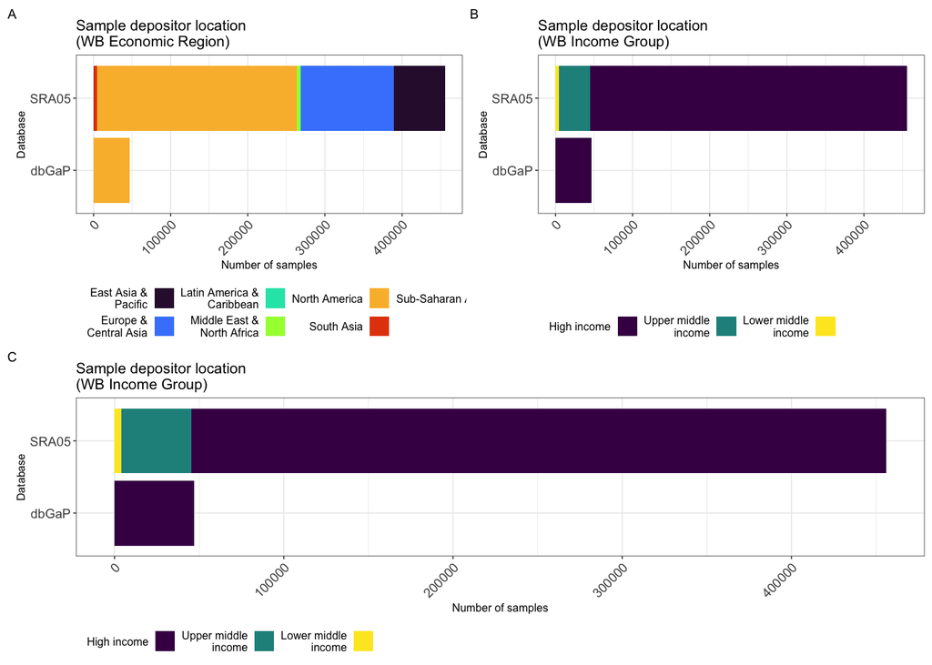

```r
names(litRevCountry)[1:3] <- c("finalCountry", "worldRegion", "worldBank")

# But this is all very annoying because it makes the plots by country and we get a lot of weird artefacts in our plots. So let's do a bit more merging of data before we plot

allCountryMain <- rbind.fill(sraCountry, sraCountryStrict, dbGapCountry, litRevCountry)
allCountryMain <- allCountryMain %>%
  mutate(worldBank = gsub("middle ", "middle\n", worldBank)) %>%
  mutate(worldBankSample = gsub("middle ", "middle\n", worldBankSample)) %>%
  mutate(hasDescriptor = if_else(grepl("dbGaP", db), "GrafPop", hasDescriptor)) %>%
  mutate(finalCountry = if_else(grepl("USA", finalCountry), "United States", finalCountry))

allCountry <- allCountryMain %>% filter(db %in% c("dbGaP", "SRA05"))
allCountryAlt <- allCountryMain %>% filter(db %in% c("dbGaP", "SRA"))

# But we want to organise the plotting of worldBank by factor levels, so:
allCountry$worldBank <- factor(allCountry$worldBank, levels = c("High income", "Upper middle\nincome", "Lower middle\nincome"))
allCountryAlt$worldBank <- factor(allCountryAlt$worldBank, levels = c("High income", "Upper middle\nincome", "Lower middle\nincome"))

dbByRegion <- allCountry %>% group_by(worldRegion, db) %>% summarise(value = sum(value), db = db) %>% distinct() %>% as.data.frame %>%
  ggplot(., aes(x = db, y=value, fill=worldRegion)) +
  geom_bar(stat = "identity") +
  ggtitle("Sample depositor location\n(WB Economic Region)") +
  xlab("Database") +
  ylab("Number of samples") +
  scale_fill_wber() +
  coord_flip() +
  guides(fill=guide_legend(title="", label.position="left")) +
  theme(axis.text.x = element_text(angle = 45, hjust=1)) +
  theme(legend.title.align = 1, legend.direction = "horizontal", legend.background=element_blank(), legend.justification = c(0,0), legend.position="bottom")
dbByRegionAlt <- allCountryAlt %>% group_by(worldRegion, db) %>% summarise(value = sum(value), db = db) %>% distinct() %>% as.data.frame %>%
  ggplot(., aes(x = db, y=value, fill=worldRegion)) +
  geom_bar(stat = "identity") +
  ggtitle("Sample depositor location\n(WB Economic Region)") +
  xlab("Database") +
  ylab("Number of samples") +
  scale_fill_wber() +
  coord_flip() +
  guides(fill=guide_legend(title="", label.position="left")) +
  theme(axis.text.x = element_text(angle = 45, hjust=1)) +
  theme(legend.title.align = 1, legend.direction = "horizontal", legend.background=element_blank(), legend.justification = c(0,0), legend.position="bottom")
dbByEconomy <- allCountry %>% group_by(worldBank, db) %>% summarise(value = sum(value), db = db) %>% distinct() %>% as.data.frame %>%
  ggplot(., aes(x = db, y=value, fill=worldBank)) +
  geom_bar(stat = "identity") +
  ggtitle("Sample depositor location\n(WB Income Group)") +
  xlab("Database") +
  ylab("Number of samples") +
  scale_fill_viridis_d(option = "viridis") +
  coord_flip() +
  guides(fill=guide_legend(title="", label.position="left")) +
  theme(axis.text.x = element_text(angle = 45, hjust=1)) +
  theme(legend.title.align = 1, legend.direction = "horizontal", legend.background=element_blank(), legend.justification = c(0,0), legend.position="bottom")
dbByEconomyAlt <- allCountryAlt %>% group_by(worldBank, db) %>% summarise(value = sum(value), db = db) %>% distinct() %>% as.data.frame %>%
  ggplot(., aes(x = db, y=value, fill=worldBank)) +
  geom_bar(stat = "identity") +
  ggtitle("Sample depositor location\n(WB Income Group)") +
  xlab("Database") +
  ylab("Number of samples") +
  scale_fill_viridis_d(option = "viridis") +
  coord_flip() +
  guides(fill=guide_legend(title="", label.position="left")) +
  theme(axis.text.x = element_text(angle = 45, hjust=1)) +
  theme(legend.title.align = 1, legend.direction = "horizontal", legend.background=element_blank(), legend.justification = c(0,0), legend.position="bottom")
# I was adding a blank space instead of a repeat of the third plot but it was messing things up with the spacing... better this way.
dbByRegion + dbByEconomy + dbByEconomy +
  plot_layout(design = mixed3DesignAlt) +
  plot_annotation(tag_levels = 'A')
```

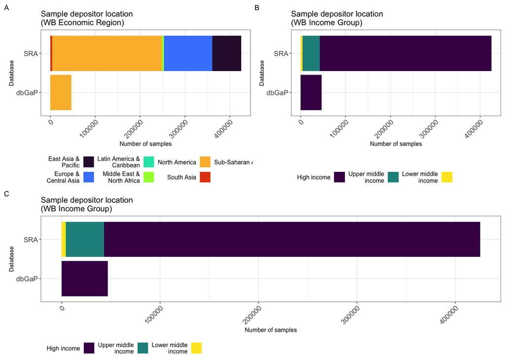

```r
ggsave("all_dbs_sample_properties_map_pre.pdf", width = 6, height = 6)
ggsave("all_dbs_sample_properties_map_pre.png", width = 6, height = 6)

# And now the strict one:
dbByRegionAlt + dbByEconomyAlt + dbByEconomyAlt +
  plot_layout(design = mixed3DesignAlt) +
  plot_annotation(tag_levels = 'A')
```

```r
ggsave("all_dbs_sample_properties_strict_map_pre.pdf", width = 6, height = 6)
ggsave("all_dbs_sample_properties_strict_map_pre.png", width = 6, height = 6)
```

How overrepresented are these numbers? We begin by grabbing the UN population data and doing some more mergers - important to note that we add back the manual review data here because otherwise it would need a figure of its own:

```r
worldPop <- read.csv("RNA-seq-diversity_world-population.csv")
worldPop$name <- gsub("Korea, South", "South Korea", worldPop$name)

allCountry2 <- allCountryMain %>%
  group_by(finalCountry, db, worldRegion) %>%
  summarise(value = sum(value)) %>%
  as.data.frame()
```

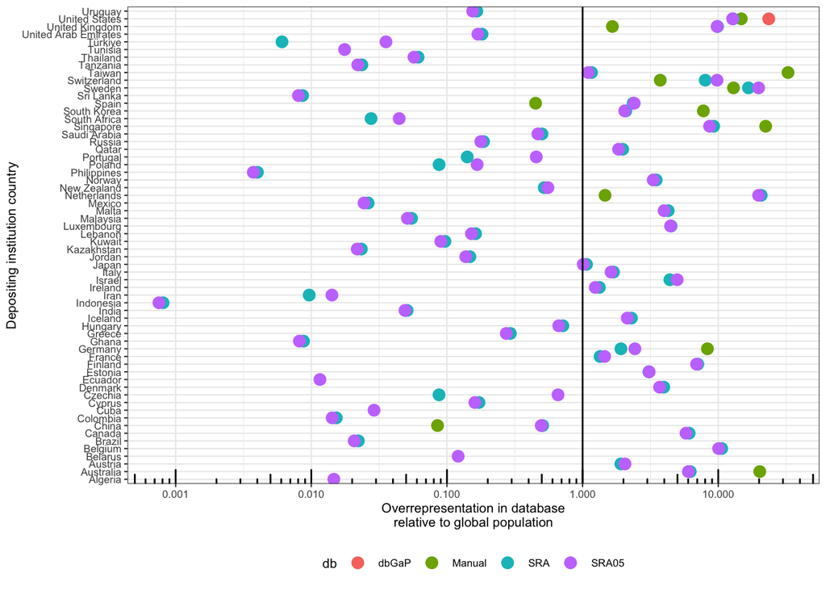

```r
allCountry3 <- left_join(allCountry2, worldPop, join_by( "finalCountry" == "name"))

# Only one NA: Turkey, which is not current in the UN numbers:
allCountry3[allCountry3$finalCountry %in% "Türkiye",]$value.y <- worldPop[worldPop$name %in% "Turkey (Turkiye)",]$value
allCountry3[allCountry3$finalCountry %in% "Türkiye",]$region <- worldPop[worldPop$name %in% "Turkey (Turkiye)",]$region

# And now we get some fancy new columns for plotting
allCountry3 <- allCountry3 %>%
  mutate(fractPop = value.y/sum(worldPop$value)) %>%
  group_by(db) %>%
  mutate(fractDB = value.x/sum(value.x)) %>%
  mutate(excess = fractDB/fractPop) %>%
  as.data.frame()

ggplot(allCountry3, aes(x = excess, y=finalCountry, color=db)) +
  geom_point(size = 3) +
  scale_x_continuous(trans='log10', breaks = trans_breaks("log10", function(x) 10^x), labels = scales::comma) +
  geom_vline(xintercept = 1) +
  annotation_logticks(sides="b") +
  xlab("Overrepresentation in database\nrelative to global population") +
  ylab("Depositing institution country") +
  theme_bw(base_size = 8) +
  theme(legend.title.align = 1, legend.direction = "horizontal", legend.background=element_blank(), legend.position="bottom")
```

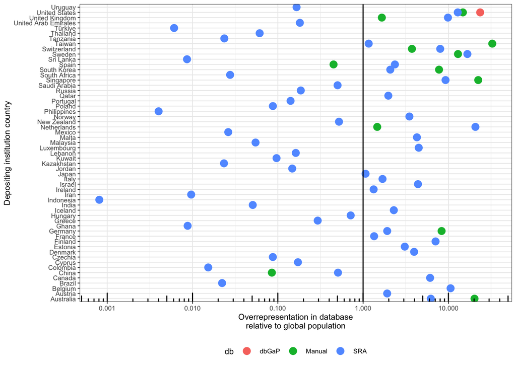

```r
# This one is for the reviewers...
ggsave("db_overrepresentation_all.pdf", width = 3, height = 8)
ggsave("db_overrepresentation_all.png", width = 3, height = 8)

# And then we make the one only with the new filtering:
allCountry3 %>% filter(db != "SRA05") %>%
ggplot(., aes(x = excess, y=finalCountry, color=db)) +
  geom_point(size = 3) +
  scale_x_continuous(trans='log10', breaks = trans_breaks("log10", function(x) 10^x), labels = scales::comma) +
  geom_vline(xintercept = 1) +
  annotation_logticks(sides="b") +
  xlab("Overrepresentation in database\nrelative to global population") +
  ylab("Depositing institution country") +
  theme_bw(base_size = 8) +
  theme(legend.title.align = 1, legend.direction = "horizontal", legend.background=element_blank(), legend.position="bottom")
```

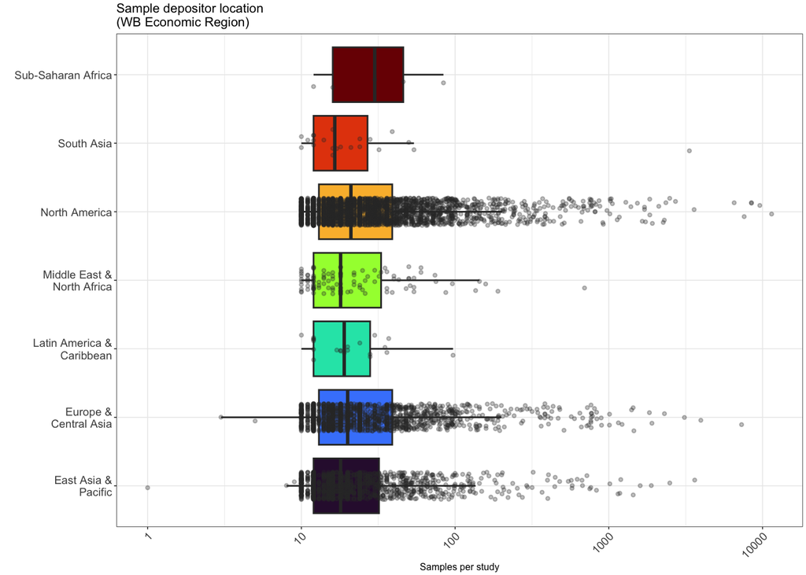

```r
# This one is for the reviewers...
ggsave("db_overrepresentation.pdf", width = 3, height = 8)
ggsave("db_overrepresentation.png", width = 3, height = 8)

# And after this we move exclusively to a Jaro-Winklar distance of 0.0 for all plots, so we gotta just a filtering step to basically everything

# We remake the plot
studybyRegion <- allSRAClean %>% drop_na(strictCountry) %>% count(SRA.Study, worldRegion) %>% drop_na(worldRegion) %>%   ggplot(., aes(x = worldRegion, y=n,fill=worldRegion)) +
    geom_boxplot(width=0.8, outlier.shape = NA) +
    geom_jitter(size=0.8, width=0.2, color="#333333", alpha = 0.3) +
    ggtitle("Sample depositor location\n(WB Economic Region)") +
    xlab("") +
    ylab("Samples per study") +
    coord_flip() +
    scale_y_continuous(trans='log10') +
    scale_fill_wber() +
    theme(axis.text.x = element_text(angle = 45, hjust=1)) +
    theme(legend.position = "none")

studybyRegion
```

```r
ggsave("allSRAClean_by_study_by_region.pdf", height=5, width=5)
ggsave("allSRAClean_by_study_by_region.png", height=5, width=5)

# But why are there studies under 10 samples???? Is it just because we can't identify country?
allSRAClean %>% drop_na(strictCountry) %>% group_by(SRA.Study) %>% summarise(biosample = n_distinct(BioSample)) %>% summarise(min(biosample))
```

```
## # A tibble: 1 × 1
##   `min(biosample)`
##              <int>
## 1                1
```

```r
allSRAClean %>% drop_na(strictCountry) %>%group_by(SRA.Study) %>% summarise(biosample = n_distinct(BioSample)) %>% summarise(min(biosample)) # Indeed.
```

```
## # A tibble: 1 × 1
##   `min(biosample)`
##              <int>
## 1                1
```

```r
# Anyhow, how bad is this bias:
allSRAClean %>% drop_na(strictCountry) %>% group_by(finalCountry) %>% summarise(samples = n()) %>% mutate(prop = samples/sum(samples)) %>% as.data.frame()
```

```
##            finalCountry samples          prop
## 1             Australia    8786 0.02066171093
## 2               Austria     906 0.00213060666
## 3               Belgium    6703 0.01576319694
## 4                Brazil     258 0.00060672905
## 5                Canada   12492 0.02937697393
## 6                 China   37932 0.08920328010
## 7              Colombia      40 0.00009406652
## 8                Cyprus      12 0.00002821996
## 9               Czechia      50 0.00011758315
## 10              Denmark    1249 0.00293722706
## 11              Estonia     194 0.00045622262
## 12              Finland    2099 0.00493614059
## 13               France    4857 0.01142202709
## 14              Germany    8508 0.02000794862
```

[output cut: 43 more lines]

```r
allSRAClean %>% drop_na(strictCountry) %>% group_by(worldBank) %>% summarise(samples = n()) %>% mutate(prop = samples/sum(samples)) %>% as.data.frame()
```

```
##             worldBank samples        prop
## 1         High income  382248 0.898918470
## 2 Lower middle income    4049 0.009521883
## 3 Upper middle income   38934 0.091559646
```

```r
# By study:
allSRAClean %>% drop_na(strictCountry) %>% group_by(finalCountry) %>% summarise(studies = n_distinct(SRA.Study)) %>% mutate(prop = studies/sum(studies)) %>% as.data.frame()
```

```
##            finalCountry studies         prop
## 1             Australia     189 0.0285930408
## 2               Austria      30 0.0045385779
## 3               Belgium      78 0.0118003026
## 4                Brazil      14 0.0021180030
## 5                Canada     190 0.0287443268
## 6                 China     749 0.1133131619
## 7              Colombia       2 0.0003025719
## 8                Cyprus       1 0.0001512859
## 9               Czechia       3 0.0004538578
## 10              Denmark      43 0.0065052950
## 11              Estonia       5 0.0007564297
## 12              Finland      83 0.0125567322
## 13               France     111 0.0167927383
## 14              Germany     177 0.0267776097
```

[output cut: 43 more lines]

```r
allSRAClean %>% drop_na(strictCountry) %>% group_by(worldBank) %>% summarise(studies = n_distinct(SRA.Study)) %>% mutate(prop = studies/sum(studies)) %>% as.data.frame()
```

```
##             worldBank studies        prop
## 1         High income    5781 0.874716296
## 2 Lower middle income      29 0.004387956
## 3 Upper middle income     799 0.120895748
```

```r
# Let's quickly do a test for how many studies and samples come from HIC relative to all studies, given in the text as 74:
hicStudyTest <- allSRAClean %>% drop_na(strictCountry) %>% group_by(worldBank) %>%
  summarise(studies = n_distinct(SRA.Study)) %>%
  mutate(prop = studies/sum(studies)) %>% as.data.frame()
binom.test(hicStudyTest[hicStudyTest$worldBank %in% "High income",]$studies, sum(hicStudyTest$studies), 0.74)
```

```
##
##  Exact binomial test
##
## data:  hicStudyTest[hicStudyTest$worldBank %in% "High income", ]$studies and sum(hicStudyTest$studies)
## number of successes = 5781, number of trials = 6609, p-value <
## 0.00000000000000022
## alternative hypothesis: true probability of success is not equal to 0.74
## 95 percent confidence interval:
##  0.8664939 0.8826064
## sample estimates:
## probability of success
##              0.8747163
```

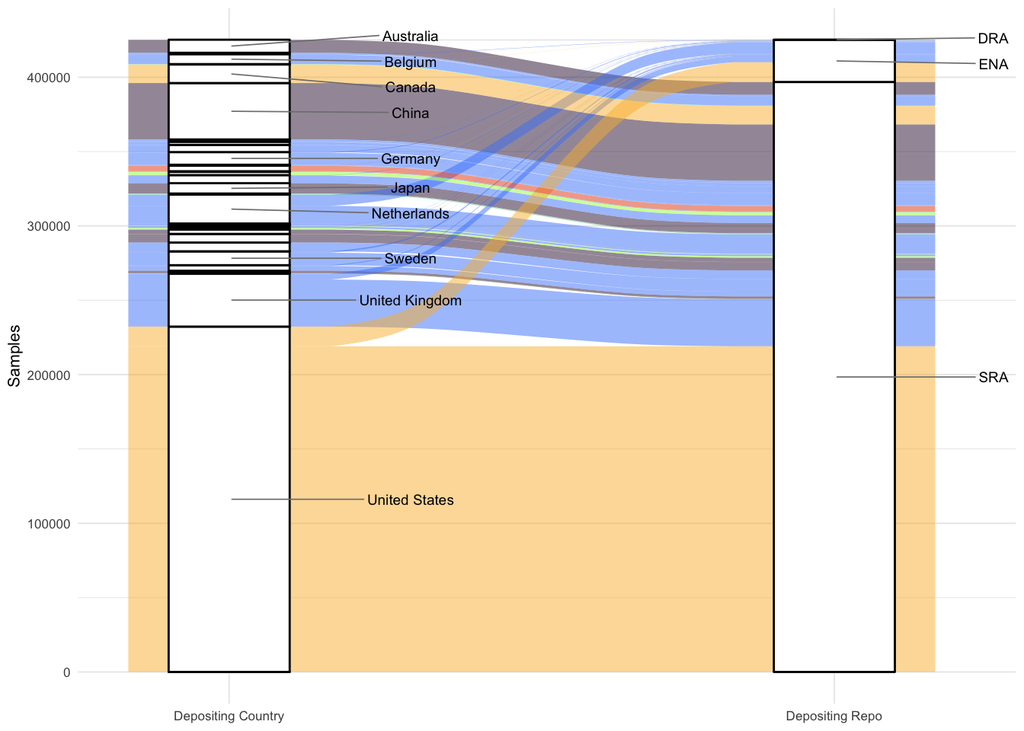

```r
# Finally, now that we have countries, we can look at who deposits from where, with some charming alluvial plot:
allSRAClean <- allSRAClean %>%
  mutate(
    repo = ifelse(grepl("^SR", SRA.Study), "SRA", ifelse(grepl("^ER", SRA.Study), "ENA", "DRA")))

# Alluvial plots and prep for the manual data only:
# For labelling, 10 most common depositing countries:
top10Countries <- allSRAClean %>% drop_na(strictCountry) %>% count(strictCountry) %>% slice_max(n, n = 10) %>%  pull(strictCountry)

repoAlluvial <- allSRAClean %>% drop_na(strictCountry) %>%
  count(strictCountry, repo, worldRegion)

ggplot(data = repoAlluvial, aes(axis2 = repo, axis1 = strictCountry, y = n)) +
   scale_x_discrete(limits = c("Depositing Country", "Depositing Repo"), expand = c(.2, .05)) +
   geom_alluvium(aes(fill = worldRegion)) +
   scale_fill_wber() +
   geom_stratum(width = 1/5) +
   ylab("Samples") +
   geom_text_repel(stat = "stratum",
                   aes(label = after_stat(ifelse(stratum %in% top10Countries | x == 2, as.character(stratum), ""))),
                   direction = "y",
                   size = 2.5,
                   nudge_x = 0.3,
                   segment.size = 0.3,
                   segment.color = "grey50",
                   min.segment.length = 0) +
   theme_minimal(base_size = 8) +
   theme(legend.position = "none")
```

```r
ggsave("repository_alluvial_for_reviewers.pdf", width = 5, height = 5)
ggsave("repository_alluvial_for_reviewers.png", width = 5, height = 5)
```

And now we’re making a map with all of this…

```r
toplot<-aggregate(BioSample~strictCountry,data=allSRAClean,FUN=length)
colnames(toplot) <- c('name','samples')
toplot$name[which(toplot$name=='United States')] <- 'United States of America'
toplot$name[which(toplot$name=='UK')] <- 'United Kingdom'
toplot$name[which(toplot$name=='Korea')] <- 'South Korea' #???
toplot$name[which(toplot$name=='Türkiye')]<- 'Turkey'

toplot2 <- ne_countries(scale='medium', returnclass = 'sf') %>%
  left_join(toplot, by = 'name')
toplot2$samples[which(is.na(toplot2$samples))]<-0

# check for any that failed to merge
toplot$name[-which(toplot$name %in% toplot2$name)]
```

```
## character(0)
```

```r
tmp<-subset(toplot2,samples>0)
table(tmp$income_grp) # Note that this is older than world bank data and doesn't include the split between lower middle and upper middle, which makes Tanzania show up as low income here
```

```
##
##    1. High income: OECD 2. High income: nonOECD  3. Upper middle income
##                      29                       8                      14
##  4. Lower middle income           5. Low income
##                       5                       1
```

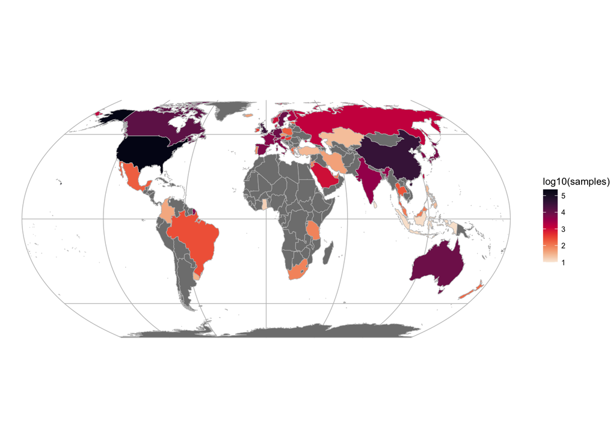

```r
ggplot(data=toplot2) +
  geom_sf(aes(fill=log10(samples)), color='grey', size=0.1) +
  coord_sf(crs = "+proj=eqearth +wktext") +
  scale_fill_viridis(option="rocket", na.value = "grey50", direction=-1) +
  theme(panel.grid.major = element_line(linewidth = 0.25, linetype = 'solid', color = "grey"),
        panel.border = element_blank(),
        axis.text.x=element_blank(),
        axis.ticks.x=element_blank()
  )
```

```r
ggsave("all_dbs_sample_properties_only_map.pdf", width = 4, height = 4)
```

Finally, we want some information on how many samples of what kind etc etc…

```r
# How many samples have a country
allSRAClean %>% count(is.na(strictCountry))
```

```
##   is.na(strictCountry)      n
## 1                FALSE 425231
## 2                 TRUE 322733
```

```r
# How many institutions?
allSRAClean %>% drop_na(strictCountry) %>% summarise(studies = n_distinct(SRA.Study), countries = n_distinct(finalCountry))
```

```
##   studies countries
## 1    6609        57
```

```r
# Overrepresentation of submitting country relative to global population:
allCountry3
```

```
##             finalCountry     db                 worldRegion value.x    value.y
## 1                Algeria  SRA05 Middle East &\nNorth Africa      39   47022473
## 2              Australia Manual        East Asia &\nPacific     229   26768598
## 3              Australia    SRA        East Asia &\nPacific    8786   26768598
## 4              Australia  SRA05        East Asia &\nPacific    9119   26768598
## 5                Austria    SRA      Europe &\nCentral Asia     906    8967982
## 6                Austria  SRA05      Europe &\nCentral Asia    1042    8967982
## 7                Belarus  SRA05      Europe &\nCentral Asia      65    9501451
## 8                Belgium    SRA      Europe &\nCentral Asia    6703   11977634
## 9                Belgium  SRA05      Europe &\nCentral Asia    6821   11977634
## 10                Brazil    SRA  Latin America &\nCaribbean     258  220051512
## 11                Brazil  SRA05  Latin America &\nCaribbean     258  220051512
## 12                Canada    SRA               North America   12492   38794813
## 13                Canada  SRA05               North America   12697   38794813
## 14                 China Manual        East Asia &\nPacific      51 1416043270
```

[output cut: 251 more lines]

```r
# We wanna test the USA, so:
usaSamples <- allSRAClean %>% filter(strictCountry == "United States") %>% nrow()
allSamples <- allSRAClean %>% drop_na(strictCountry) %>% nrow()
usaProp <- allCountry3[allCountry3$finalCountry %in% "United States" & allCountry3$db %in% "SRA" , ]$fractPop[1]

# And finally, a binomial test for the USA
binom.test(usaSamples, allSamples, usaProp)
```

```
##
##  Exact binomial test
##
## data:  usaSamples and allSamples
## number of successes = 232251, number of trials = 425231, p-value <
## 0.00000000000000022
## alternative hypothesis: true probability of success is not equal to 0.04244169
## 95 percent confidence interval:
##  0.5446782 0.5476733
## sample estimates:
## probability of success
##              0.5461761
```

```r
# We also want to test this against the proportion of samples from the USA in microbiome studies, which we cite in the text as being 40%
binom.test(usaSamples, allSamples, 0.4)
```

```
##
##  Exact binomial test
##
## data:  usaSamples and allSamples
## number of successes = 232251, number of trials = 425231, p-value <
## 0.00000000000000022
## alternative hypothesis: true probability of success is not equal to 0.4
## 95 percent confidence interval:
##  0.5446782 0.5476733
## sample estimates:
## probability of success
##              0.5461761
```

```r
# And another one for institutions in LATAM + Caribbean
latamSamples <- allCountry3 %>% filter(worldRegion == "Latin America &\nCaribbean" & db == "SRA") %>%
  summarise(samples = sum(value.x)) %>%
  mutate(proportion = samples/allSamples)

# But to do the test we need to know how many people live in LATAM...
latamProp <- worldPop %>% filter(region %in% c("Central America and the Caribbean", "South America")) %>% summarise(sum(value))/sum(worldPop$value)

binom.test(latamSamples$samples, allSamples, latamProp[1,1])
```

```
##
##  Exact binomial test
##
## data:  latamSamples$samples and allSamples
## number of successes = 509, number of trials = 425231, p-value <
## 0.00000000000000022
## alternative hypothesis: true probability of success is not equal to 0.06654691
## 95 percent confidence interval:
##  0.001095308 0.001305576
## sample estimates:
## probability of success
##            0.001196996
```

```r
#And some stats on the Razi et al subset:
allSRAClean %>% drop_na(pred_pop) %>% filter(missingness %in% c("(0,10]", "(10,20]", "(20,30]")) %>% count(pred_pop) %>% mutate(freq = n/sum(n))
```

```
##       pred_pop     n       freq
## 1 1KG-AFR-like 13530 0.12865375
## 2 1KG-EUR-like 41316 0.39286461
## 3 1KG-SAS-like  4810 0.04573722
## 4 1KG-EAS-like 10905 0.10369321
## 5 1KG-AMR-like 34605 0.32905121
```

```r
allSRAClean %>% drop_na(pred_pop) %>% filter(missingness %in% c("(0,10]", "(10,20]", "(20,30]")) %>% summarise(studies = n_distinct(SRA.Study), samples = n_distinct(BioSample))
```

```
##   studies samples
## 1    3540  105166
```

```r
allSRAClean %>% drop_na(pred_pop) %>% summarise(studies = n_distinct(SRA.Study), samples = n_distinct(BioSample))
```

```
##   studies samples
## 1   12291  747964
```

And one final check… the agreement in country assignment between our two methods.

```r
finalCountries <- allSRAFinal %>% count(SRA.Study, finalCountry) # 248 rows because one study is deposited from multiple sites

finalCountries %>% group_by(SRA.Study) %>%
  filter(n() > 1)
```

```
## # A tibble: 5 × 3
## # Groups:   SRA.Study [1]
##   SRA.Study finalCountry     n
##   <chr>     <chr>        <int>
## 1 ERP001942 Belgium         42
## 2 ERP001942 Germany        175
## 3 ERP001942 Spain           95
## 4 ERP001942 Sweden          42
## 5 ERP001942 Switzerland    110
```

```r
cleanCountries <- allSRAClean %>% count(SRA.Study, strictCountry) # 12303 rows because there's some studies with partial NAs...
cleanCountries %>% group_by(SRA.Study) %>%
  filter(n() > 1) %>%
  as.data.frame()
```

```
##    SRA.Study  strictCountry   n
## 1  ERP001942        Germany 110
## 2  ERP001942           <NA> 354
## 3  ERP007111  United States 142
## 4  ERP007111           <NA> 190
## 5  ERP010353 United Kingdom   3
## 6  ERP010353           <NA>   8
## 7  ERP016268      Singapore   9
## 8  ERP016268  United States  10
## 9  ERP123567 United Kingdom  22
## 10 ERP123567           <NA>  18
## 11 SRP000941        Austria   5
## 12 SRP000941           <NA>  57
## 13 SRP073253  United States  43
## 14 SRP073253           <NA>   3
## 15 SRP078289    South Korea   8
## 16 SRP078289           <NA>  29
## 17 SRP133673  United States  27
## 18 SRP133673           <NA>  34
## 19 SRP266877  United States  15
## 20 SRP266877           <NA>  15
## 21 SRP320421          China   1
## 22 SRP320421           <NA>  11
## 23 SRP340395  United States  30
## 24 SRP340395           <NA>   3
```

```r
# For example:
allSRAClean[allSRAClean$SRA.Study %in% "SRP320421",]
```

```
##        SRA.Study                                              Center.Name
## 638607 SRP320421        INSTITUTE OF VIROLOGY, CHINESE ACADEMY OF SCIENCE
## 638608 SRP320421        INSTITUTE OF VIROLOGY, CHINESE ACADEMY OF SCIENCE
## 644389 SRP320421        INSTITUTE OF VIROLOGY, CHINESE ACADEMY OF SCIENCE
## 645236 SRP320421 WUHAN INSTITUTE OF VIROLOGY, CHINESE ACADEMY OF SCIENCES
## 645793 SRP320421        INSTITUTE OF VIROLOGY, CHINESE ACADEMY OF SCIENCE
## 645860 SRP320421        INSTITUTE OF VIROLOGY, CHINESE ACADEMY OF SCIENCE
## 645861 SRP320421        INSTITUTE OF VIROLOGY, CHINESE ACADEMY OF SCIENCE
## 645862 SRP320421        INSTITUTE OF VIROLOGY, CHINESE ACADEMY OF SCIENCE
## 645863 SRP320421        INSTITUTE OF VIROLOGY, CHINESE ACADEMY OF SCIENCE
## 645864 SRP320421        INSTITUTE OF VIROLOGY, CHINESE ACADEMY OF SCIENCE
## 645865 SRP320421        INSTITUTE OF VIROLOGY, CHINESE ACADEMY OF SCIENCE
## 645866 SRP320421        INSTITUTE OF VIROLOGY, CHINESE ACADEMY OF SCIENCE
##           BioSample     Organism  LibrarySource Cell_type
## 638607 SAMN25982226 Homo sapiens TRANSCRIPTOMIC      <NA>
```

[output cut: 167 more lines]

```r
allSRAClean[allSRAClean$SRA.Study %in% "ERP010353",]
```

```
##        SRA.Study                         Center.Name    BioSample     Organism
## 173232 ERP010353           WELLCOME SANGER INSTITUTE SAMEA3672898 Homo sapiens
## 173233 ERP010353           WELLCOME SANGER INSTITUTE SAMEA3672899 Homo sapiens
## 173234 ERP010353           WELLCOME SANGER INSTITUTE SAMEA3672900 Homo sapiens
## 173780 ERP010353 THE WELLCOME TRUST SANGER INSTITUTE SAMEA3367447 Homo sapiens
## 173781 ERP010353 THE WELLCOME TRUST SANGER INSTITUTE SAMEA3367591 Homo sapiens
## 173782 ERP010353 THE WELLCOME TRUST SANGER INSTITUTE SAMEA3367592 Homo sapiens
## 173783 ERP010353 THE WELLCOME TRUST SANGER INSTITUTE SAMEA3367593 Homo sapiens
## 173784 ERP010353 THE WELLCOME TRUST SANGER INSTITUTE SAMEA3367594 Homo sapiens
## 173785 ERP010353 THE WELLCOME TRUST SANGER INSTITUTE SAMEA3367595 Homo sapiens
## 173786 ERP010353 THE WELLCOME TRUST SANGER INSTITUTE SAMEA3367596 Homo sapiens
## 173787 ERP010353 THE WELLCOME TRUST SANGER INSTITUTE SAMEA3367597 Homo sapiens
##         LibrarySource Cell_type Tissue Cell_line disease ETHNICITY
## 173232 TRANSCRIPTOMIC      <NA>   <NA>      <NA>    <NA>      <NA>
## 173233 TRANSCRIPTOMIC      <NA>   <NA>      <NA>    <NA>      <NA>
```

[output cut: 153 more lines]

```r
compareCountries <- left_join(finalCountries, cleanCountries, join_by("SRA.Study" == "SRA.Study"))
# And now we tabulate:
compareCountries %>%
  mutate(strictCountry = gsub("United States", "USA", strictCountry)) %>%
  group_by(SRA.Study, finalCountry) %>%
  summarise(
    has_match = any(!is.na(strictCountry) & strictCountry == finalCountry),
    has_mismatch = any(!is.na(strictCountry) & strictCountry != finalCountry),
    has_na = any(is.na(strictCountry)),
    n.x = first(n.x),
    .groups = "drop"
  ) %>%
  mutate(category = case_when(
    has_match & !has_mismatch & !has_na ~ "full match",
    has_mismatch & !has_match & !has_na ~ "full mismatch",
    has_na & !has_match & !has_mismatch ~ "all NA",
    has_match & has_na & !has_mismatch ~ "match + NA",
    has_mismatch & has_na & !has_match ~ "mismatch + NA",
    TRUE ~ "other"
  )) %>%
  group_by(category) %>%
  summarise(n_studies = n(), total_n.x = sum(n.x))
```

```
## # A tibble: 5 × 3
##   category      n_studies total_n.x
##   <chr>             <int>     <int>
## 1 all NA              103     11743
## 2 full match          116     10371
## 3 full mismatch        21       841
## 4 match + NA            2       190
## 5 mismatch + NA         6       658
```

```r
# But that's comfused about the matches, so to know the proper number, we need to merge the two objects at the raw data level:

allSRACheck <- left_join(allSRAFinal, allSRAClean, by = c("BioSample"))
allSRACheck %>%
  mutate(strictCountry = gsub("United States", "USA", strictCountry)) %>%
  summarise(
    has_match = sum(!is.na(strictCountry) & strictCountry == finalCountry.x),
    has_mismatch = sum(!is.na(strictCountry) & strictCountry != finalCountry.x),
    has_na = sum(is.na(strictCountry)))
```

```
##   has_match has_mismatch has_na
## 1     10481          983  12339
```

Bearing this in mind we actually want to compare country of deposition of all studies vs country of deposition of studies with metadata. This is inherently noisy (116:21 above) but what can you do?

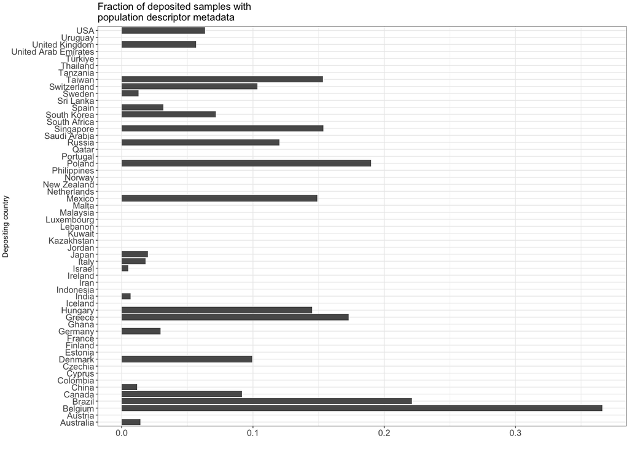

```r
allSamplesClean <- allSRAClean %>% drop_na(strictCountry) %>% count(finalCountry) %>% mutate(finalCountry = gsub("United States", "USA", finalCountry))
allSamplesFinal <- allSRAFinal %>% count(finalCountry)

sampleRep <- left_join(allSamplesClean, allSamplesFinal, by = c("finalCountry"))
sampleRep <- sampleRep %>% mutate(
  n.y = ifelse(is.na(n.y), 0, n.y),
  frac = n.y/n.x)

ggplot(sampleRep, aes(y = finalCountry, x = frac)) +
  geom_bar(stat = "identity") +
  ggtitle("Fraction of deposited samples with\npopulation descriptor metadata") +
  xlab("") +
  ylab("Depositing country") +
  # scale_fill_wber() +
  # theme(axis.text.x = element_text(angle = 45, hjust=1)) +
  theme(legend.title.align = 1, legend.direction = "horizontal", legend.background=element_blank(), legend.justification = c(0,0), legend.position="bottom")
```

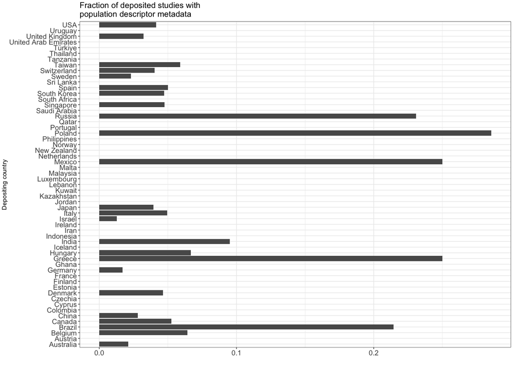

```r
ggsave("samples_with_metadata.pdf", width=3, height=5)
ggsave("samples_with_metadata.png", width=3, height=5)

allStudiesClean <- allSRAClean %>% drop_na(strictCountry) %>% distinct(SRA.Study, .keep_all=T) %>% count(finalCountry)  %>% mutate(finalCountry = gsub("United States", "USA", finalCountry))
allStudiesFinal <- allSRAFinal %>% distinct(SRA.Study, .keep_all=T) %>% count(finalCountry)
studyRep <- left_join(allStudiesClean, allStudiesFinal, by = c("finalCountry"))

# setdiff(unique(allStudiesFinal$finalCountry), unique(allStudiesClean$finalCountry))

studyRep <- studyRep %>% mutate(
  n.y = ifelse(is.na(n.y), 0, n.y),
  frac = n.y/n.x)

ggplot(studyRep, aes(y = finalCountry, x = frac)) +
  geom_bar(stat = "identity") +
  ggtitle("Fraction of deposited studies with\npopulation descriptor metadata") +
  xlab("") +
  ylab("Depositing country") +
  # scale_fill_wber() +
  # theme(axis.text.x = element_text(angle = 45, hjust=1)) +
  theme(legend.title.align = 1, legend.direction = "horizontal", legend.background=element_blank(), legend.justification = c(0,0), legend.position="bottom")
```

```r
ggsave("studies_with_metadata.pdf", width=3, height=5)
ggsave("studies_with_metadata.png", width=3, height=5)
```

## Figure 2: Sample breakdown by descriptor

My original idea: Current 2A, 2D, 2C, then two new panels using Kasper’s data - one equivalent to what we have now, and the PCA plot. Note that we need to decide whether to subset on missingness on his data, it changes proportions. Still haven’t heard back, will send them a new email soon. Will need to update text. Possibly the alluvial plot or the little table as a third new panel showing correspondence between label and genotype, so we can drill down on the inadequacy of descriptors for capturing admixture.

Amanda’s suggestion: Yes, 2A, 2C, 2D should stay here. I might vote for a new fig 3 that includes the manual review panels (2B, 2E) plus 2 panels about Kasper’s data since currently those results are in the next section. In that case, we could combine Fig 3 and 4 (the barplots could definitely be thinner width wise with the x-axis labels rotated to a full 90 angle, so we could aim for a 2x2 layout). What do you think?

I tried Amanda’s version but while the new figure 2 looks ok, I think the Razi et al data makes no sense next to the manual review, so I’m making a couple of different versions for her, and then a new manual with the alluvial plot.

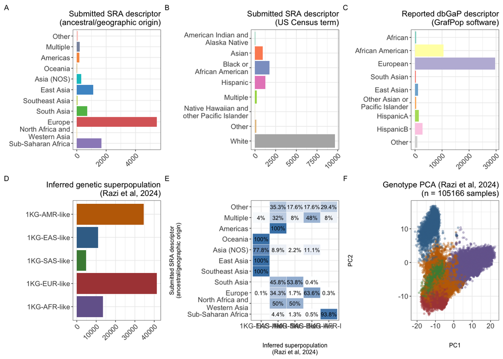

```r
geographyProp <- allSRAFinal %>% drop_na(strictestGeography) %>% count(strictestGeography) %>% mutate(freq = n/sum(n))
raceProp <- allSRAFinal %>% drop_na(strictestRace) %>% count(strictestRace) %>% mutate(freq = n/sum(n))

# These two are calculated here because they're used below. They have to be remade for plotting because of how the script was structured, but YOLO..
litRevGeoProp <- litRevFinal %>% drop_na(finalGeo) %>% group_by(finalGeo) %>% summarise(n = sum(individs)) %>% mutate(freq = n/sum(n))
litRevRaceProp <- litRevFinal %>% drop_na(finalRace) %>% group_by(finalRace) %>% summarise(n = sum(individs)) %>% mutate(freq = n/sum(n))

dbgapProp <- dbGapFinal %>% group_by(variable) %>% summarise(n = sum(value)) %>% mutate(freq = n/sum(n))

raziProp <- allSRAClean %>% drop_na(pred_pop) %>% filter(missingness %in% c("(0,10]", "(10,20]", "(20,30]")) %>% count(pred_pop) %>% mutate(freq = n/sum(n))

# And then we want to know about concordance between Razi et al and author-reported descriptors.
confMatrix <- allSRAFinal %>% drop_na(pred_pop) %>% drop_na(strictestGeography) %>% filter(missingness %in% c("(0,10]", "(10,20]", "(20,30]")) %>% count(strictestGeography, pred_pop)

df_cm <- melt(confMatrix)
df_cm$Percentage <- round(100 * df_cm$value / sum(df_cm$value), 1)

df_cm <- df_cm %>% group_by(pred_pop) %>% mutate(percentGA = round(100 * value/sum(value), 1))
df_cm <- df_cm %>% group_by(strictestGeography) %>% mutate(percentRep = round(100 * value/sum(value), 1))

# Reverse the order of Predicted factor levels for pretty plotting:
df_cm$pred_pop <- factor(df_cm$pred_pop, levels = rev(unique(df_cm$pred_pop)))

geoPlot <- ggplot(geographyProp, aes(x = fct_inorder(strictestGeography), y = n, fill = strictestGeography)) +
  geom_bar(stat="identity") +
  ggtitle("Submitted SRA descriptor\n(ancestral/geographic origin)") +
  xlab(NULL) +
  ylab(NULL) +
  coord_flip() +
  scale_fill_geography() +
  theme(axis.text.x = element_text(angle = 45, hjust=1)) +
  theme(legend.position="none") +
  theme(plot.title = element_text(hjust = 1))

racePlot <- ggplot(raceProp, aes(x = fct_rev(fct_inorder(strictestRace)), y = n, fill=strictestRace)) +
  geom_bar(stat="identity") +
  ggtitle("Submitted SRA descriptor\n(US Census term)") +
  xlab(NULL) +
  ylab(NULL) +
  coord_flip() +
  scale_fill_race() +
  theme(axis.text.x = element_text(angle = 45, hjust=1)) +
  theme(legend.position="none") +
  theme(plot.title = element_text(hjust = 1))

raziPlot <- ggplot(raziProp, aes(x = fct_inorder(pred_pop), y = n, fill = pred_pop)) +
  geom_bar(stat="identity") +
  ggtitle("Inferred genetic superpopulation\n(Razi et al, 2024)") +
  xlab(NULL) +
  ylab(NULL) +
  coord_flip() +
  scale_fill_kasper() +
  theme(axis.text.x = element_text(angle = 45, hjust=1)) +
  theme(legend.position="none") +
  theme(plot.title = element_text(hjust = 1))

raziPCA <- allSRAClean %>% drop_na(pred_pop) %>% filter(missingness %in% c("(0,10]", "(10,20]", "(20,30]")) %>%
  ggplot(., aes(x = pc1, y = pc2, color=pred_pop )) +
    ggtitle(paste0("Genotype PCA (Razi et al, 2024)\n(n = ", sum(raziProp$n), " samples)")) +
    geom_point(alpha = 0.3, size = 0.5) +
    ylab("PC2") +
    xlab("PC1") +
    theme(plot.title = element_text(hjust = 1)) +
    scale_color_kasper() +
    labs(color="Predicted\nSuperpopulation") +
    theme(legend.position = "none")

confMatrixPlot <- ggplot(df_cm, aes(x = pred_pop, y = strictestGeography, fill = percentRep)) +
  geom_tile(color = "white") +
  geom_text(aes(label = ifelse(value == 0, "", paste0(percentRep, "%"))),
            size = 2, color = "black") +
  scale_fill_gradient(low = "white", high = "steelblue") +
  xlab("Inferred superpopulation\n(Razi et al, 2024)") +
  ylab("Submitted SRA descriptor\n(ancestral/geographic origin)") +
  theme(legend.position = "none")

dbgapPlot <- ggplot(dbgapProp, aes(x = fct_rev(fct_inorder(variable)), y = n, fill=variable)) +
  geom_bar(stat="identity") +
  ggtitle("Reported dbGaP descriptor\n(GrafPop software)") +
  xlab(NULL) +
  ylab(NULL) +
  coord_flip() +
  scale_fill_dbGap() +
  theme(axis.text.x = element_text(angle = 45, hjust=1)) +
  theme(legend.position="none") +
  theme(plot.title = element_text(hjust = 1))

geoPlot + racePlot + dbgapPlot + raziPlot + confMatrixPlot + raziPCA +
    plot_layout(design = long6Design, tag_level = 'new') +
    plot_annotation(tag_levels = 'A')
```

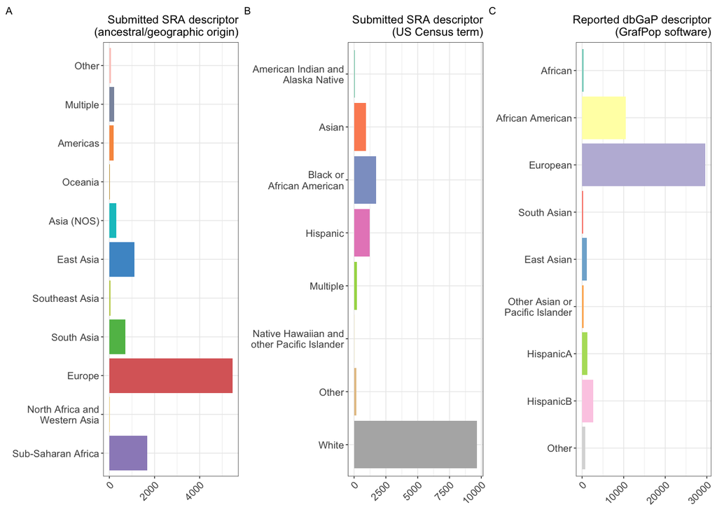

```r
ggsave("no_manual_dbs_descriptors_razi.pdf", width = 7, height = 4.5)
ggsave("no_manual_dbs_descriptors_razi.png", width = 7, height = 4.5)

geoPlot + racePlot + dbgapPlot +
    plot_layout(design = wide3Design, tag_level = 'new') +
    plot_annotation(tag_levels = 'A')
```

```r
ggsave("no_manual_dbs_descriptors.pdf", width = 7, height = 2.5)
ggsave("no_manual_dbs_descriptors.png", width = 7, height = 2.5)
```

Working out the overrepresentation of countries in the datasets, so I can make that second supplementary plot. We grab the population regions from the toplot2 object Amanda had as a good starting point:

```r
worldPop <- left_join(worldPop, toplot2[,c(19,93:96)], by = "name")
worldPop <- worldPop[,-8]

worldPopNA <- worldPop[is.na(worldPop$subregion),]
worldPopOk <- worldPop %>% filter(!is.na(subregion))

worldPopNA <- worldPopNA %>%
  mutate(subregion = ifelse(grepl("America", region), "Americas", subregion)) %>%
  mutate(subregion = ifelse(grepl("Australia and Oceania", region), "Oceania", subregion)) %>%
  mutate(subregion = ifelse(grepl("Europe", region), "Europe", subregion)) %>%
  mutate(subregion = ifelse(grepl("Middle East", region), "North AF and WA", subregion)) %>%
  mutate(subregion = ifelse(grepl("Africa", region), "Sub-Saharan Africa", subregion)) %>%
  mutate(subregion = ifelse(grepl("Korea, North|Macau|Paracel", name), "East Asia", subregion)) %>%
  mutate(subregion = ifelse(grepl("Burma", name), "Southeast Asia", subregion))

worldPop2 <- rbind(worldPopNA, worldPopOk)
```

… and we stop there until we work out what to do with all the Europeans outside Europe!

Lol the internet suggested just adding the number of Europeans outside Europe, and the best source I could find was the Wikipedia page on the European diaspora (at least I saved it to Zotero. Technically should be able to read in those numbers and, uh, substract them from the countries, and recompute stuff? But that is such BS…)

I removed overseas holdings of European countries to avoid double counting (Ceuta, Melilla, New Caledonia, etc), and also countries that the world bank says are European (Russia, one of the stans)

```r
euros <- read.csv("20240901_European_diaspora_data.csv")
africans <- read.csv("20240901_African_diaspora_data.csv")

# Let's drop the mixed ones? I don't know what to do with them... If I don't I end up double-counting a LOT of Brazilians
euros <- euros %>% filter(!grepl("mixed", Note))
africans <- africans %>% filter(!grepl("mixed", Note)) %>%
  mutate(Country = ifelse(grepl("Turkey", Country), "Turkey (Turkiye)", Country))

worldPop3 <- left_join(worldPop2, euros, join_by("name" == "Country") )
worldPop3 <- left_join(worldPop3, africans, join_by("name" == "Country") )

worldPop3 <- worldPop3 %>%
  mutate(European = ifelse(is.na(European), 0, European)) %>%
  mutate(African = ifelse(is.na(African), 0, African)) %>%
  mutate(nonEuroPop = value - European) %>%
  mutate(nonAFR = value - African) %>%
  mutate(noneither = value - European - African)

head(worldPop3)
```

```
##                                name     value                  region continent
## 1                     United States 341963408           North America      <NA>
## 2 Congo, Democratic Republic of the 115403027                  Africa      <NA>
## 3                  Turkey (Turkiye)  84119531             Middle East      <NA>
## 4                             Burma  57527139 East and Southeast Asia      <NA>
## 5                     Cote d'Ivoire  29981758                  Africa      <NA>
## 6                      Korea, North  26298666 East and Southeast Asia      <NA>
##   region_un          subregion region_wb  European Note.x  African Note.y
## 1      <NA>           Americas      <NA> 204277273        41104200
## 2      <NA> Sub-Saharan Africa      <NA>         0   <NA>        0   <NA>
## 3      <NA>    North AF and WA      <NA>         0   <NA>   100000
## 4      <NA>     Southeast Asia      <NA>         0   <NA>        0   <NA>
## 5      <NA> Sub-Saharan Africa      <NA>         0   <NA>        0   <NA>
## 6      <NA>          East Asia      <NA>         0   <NA>        0   <NA>
##   nonEuroPop    nonAFR noneither
## 1  137686135 300859208  96581935
## 2  115403027 115403027 115403027
## 3   84119531  84019531  84019531
## 4   57527139  57527139  57527139
## 5   29981758  29981758  29981758
## 6   26298666  26298666  26298666
```

```r
regionalPop <- worldPop3 %>% group_by(subregion) %>%
  summarise(population = sum(value), euro = sum(European), noneuro = sum(nonEuroPop), afr = sum(African), nonafr = sum(nonAFR), others = sum(noneither)) %>% as.data.frame()

# This also needs a bit more cleaning:
regionalPop <- regionalPop %>%
  mutate(subregion = gsub("Northern Africa|Western Asia", "North AF and WA", subregion)) %>%
  mutate(subregion = ifelse(grepl("Africa", subregion), "Sub-Saharan Africa", subregion)) %>%
  mutate(subregion = ifelse(grepl("Europe", subregion), "Europe", subregion)) %>%
  mutate(subregion = ifelse(grepl("America", subregion), "Americas", subregion)) %>%
  mutate(subregion = gsub("Australia and New Zealand|Melanesia|Micronesia|Polynesia", "Oceania", subregion)) %>%
  mutate(subregion = gsub("Caribbean", "Americas", subregion)) %>%
  mutate(subregion = gsub("South-Eastern Asia", "Southeast Asia", subregion)) %>%
  mutate(subregion = gsub("Eastern Asia", "East Asia", subregion)) %>%
  mutate(subregion = gsub("Southern Asia", "South Asia", subregion)) %>%
  mutate(subregion = gsub("North AF and WA", "North Africa and\nWestern Asia", subregion)) %>%
  group_by(subregion) %>% summarise(population = sum(population), euro = sum(euro), noneuro = sum(noneuro), afr = sum(afr), nonafr = sum(nonafr), others = sum(others))

regionalPop
```

```
## # A tibble: 9 × 7
##   subregion                       population   euro noneuro    afr nonafr others
##   <chr>                                <int>  <dbl>   <dbl>  <dbl>  <dbl>  <dbl>
## 1 "Americas"                      1047819112 4.87e8  5.61e8 8.95e7 9.58e8 4.71e8
## 2 "Central Asia"                    79090914 4.09e6  7.50e7 0      7.91e7 7.50e7
## 3 "East Asia"                     1652446317 0       1.65e9 0      1.65e9 1.65e9
## 4 "Europe"                         742084882 0       7.42e8 1.15e7 7.31e8 7.31e8
## 5 "North Africa and\nWestern Asi…  556654119 2.8 e6  5.54e8 1.00e7 5.47e8 5.44e8
## 6 "Oceania"                         45531556 2.52e7  2.03e7 3.27e5 4.52e7 2.00e7
## 7 "South Asia"                    2013075939 0       2.01e9 2.70e5 2.01e9 2.01e9
## 8 "Southeast Asia"                 700655943 0       7.01e8 0      7.01e8 7.01e8
## 9 "Sub-Saharan Africa"            1219894219 4.95e6  1.21e9 0      1.22e9 1.21e9
```

```r
# And now we're finally ready to compare things!
regionalPop2 <- regionalPop %>%
  mutate(euro = ifelse(grepl("Europe", subregion), population - afr, euro)) %>%
  mutate(afr = ifelse(grepl("Sub-Saharan Africa", subregion), population - euro, afr)) %>%
  mutate(global = ifelse(grepl("Sub-Saharan Africa", subregion), sum(afr), others)) %>%
  mutate(global = ifelse(grepl("Europe", subregion), sum(euro), global)) %>%
  mutate(fractPop = global/sum(global)) %>%
  mutate(sanityCheck = euro + afr + global - population)

regionalPop2 # that gets me to 15.6% for Europe... so we'll go with that even though it's terrible
```

```
## # A tibble: 9 × 10
##   subregion       population   euro noneuro    afr nonafr others global fractPop
##   <chr>                <int>  <dbl>   <dbl>  <dbl>  <dbl>  <dbl>  <dbl>    <dbl>
## 1 "Americas"      1047819112 4.87e8  5.61e8 8.95e7 9.58e8 4.71e8 4.71e8  0.0585
## 2 "Central Asia"    79090914 4.09e6  7.50e7 0      7.91e7 7.50e7 7.50e7  0.00931
## 3 "East Asia"     1652446317 0       1.65e9 0      1.65e9 1.65e9 1.65e9  0.205
## 4 "Europe"         742084882 7.31e8  7.42e8 1.15e7 7.31e8 7.31e8 1.25e9  0.156
## 5 "North Africa …  556654119 2.8 e6  5.54e8 1.00e7 5.47e8 5.44e8 5.44e8  0.0675
## 6 "Oceania"         45531556 2.52e7  2.03e7 3.27e5 4.52e7 2.00e7 2.00e7  0.00248
## 7 "South Asia"    2013075939 0       2.01e9 2.70e5 2.01e9 2.01e9 2.01e9  0.250
## 8 "Southeast Asi…  700655943 0       7.01e8 0      7.01e8 7.01e8 7.01e8  0.0870
## 9 "Sub-Saharan A… 1219894219 4.95e6  1.21e9 1.21e9 1.22e9 1.21e9 1.33e9  0.165
## # ℹ 1 more variable: sanityCheck <dbl>
```

```r
geographyProp <- left_join(geographyProp, regionalPop2, join_by( "strictestGeography" == "subregion"))
litRevGeoProp <- left_join(litRevGeoProp, regionalPop2, join_by( "finalGeo" == "subregion"))

geographyProp$db <- "SRA"
litRevGeoProp$db <- "Manual"
names(litRevGeoProp)[1] <- "strictestGeography"

allGeoProps <- rbind(geographyProp, litRevGeoProp)
allGeoProps <- allGeoProps %>%
  filter(!is.na(population)) %>%
  mutate(excess = freq/fractPop)

# And then yet another binomial test, this time checking if the proportion of samples in the manual is a similar draw to the SRA:
eurSRAprop <- allGeoProps %>% filter(db == "SRA") %>% filter(strictestGeography == "Europe") %>% summarise (freq = freq)
eurLitHits <- allGeoProps %>% filter(db == "Manual") %>% filter(strictestGeography == "Europe") %>% summarise (freq = n)
litRevTotals <- litRevFinal %>% filter(!is.na(finalGeo)) %>% summarise(inds = sum(individs))
binom.test(eurLitHits[1,1], litRevTotals[1,1], eurSRAprop[1,1])
```

```
##
##  Exact binomial test
##
## data:  eurLitHits[1, 1] and litRevTotals[1, 1]
## number of successes = 1076, number of trials = 2058, p-value = 0.002547
## alternative hypothesis: true probability of success is not equal to 0.5560543
## 95 percent confidence interval:
##  0.5009957 0.5446146
## sample estimates:
## probability of success
##              0.5228377
```

```r
# And to GWAS data (90.5% per GWAS monitor on 2025.06.29)
binom.test(geographyProp[geographyProp$strictestGeography %in% "Europe",]$n, sum(geographyProp$n), 0.905)
```

```
##
##  Exact binomial test
##
## data:  geographyProp[geographyProp$strictestGeography %in% "Europe", ]$n and sum(geographyProp$n)
## number of successes = 5451, number of trials = 9803, p-value <
## 0.00000000000000022
## alternative hypothesis: true probability of success is not equal to 0.905
## 95 percent confidence interval:
##  0.5461524 0.5659228
## sample estimates:
## probability of success
##              0.5560543
```

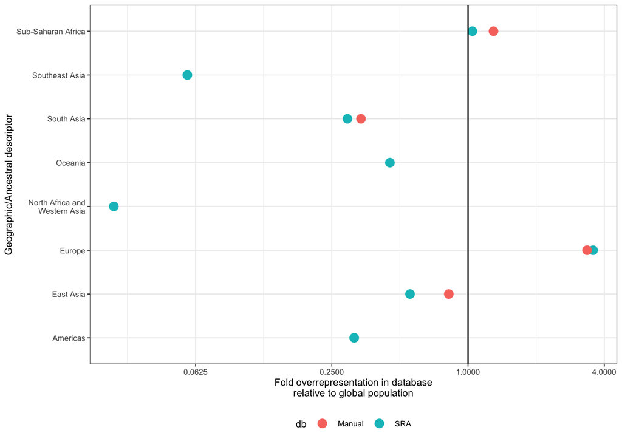

```r
# Now the plot:
ggplot(allGeoProps, aes(x = excess, y=strictestGeography, color=db)) +
  geom_point(size = 3) +
  # scale_x_continuous(trans='log2', breaks = trans_breaks("log2", function(x) 2^x), labels = trans_format("log2", math_format(2^.x))) +
  scale_x_continuous(trans='log2', breaks = trans_breaks("log2", function(x) 2^x)) +
  geom_vline(xintercept = 1) +
  # annotation_logticks(sides="b") +
  xlab("Fold overrepresentation in database\nrelative to global population") +
  ylab("Geographic/Ancestral descriptor") +
  theme_bw(base_size = 8) +
  theme(legend.title.align = 1, legend.direction = "horizontal", legend.background=element_blank(), legend.position="bottom")
```

```r
ggsave("global_overrepresentation.pdf", width = 3, height = 5)
ggsave("global_overrepresentation.png", width = 3, height = 5)
```

We can’t do the same for dbGap, because it’s a mixture of terms, but at least European is fairly homogeneous, so we can do that much:

```r
eurdbGapProp <- dbgapProp %>% filter(variable == "European")
regionalPop2
```

```
## # A tibble: 9 × 10
##   subregion       population   euro noneuro    afr nonafr others global fractPop
##   <chr>                <int>  <dbl>   <dbl>  <dbl>  <dbl>  <dbl>  <dbl>    <dbl>
## 1 "Americas"      1047819112 4.87e8  5.61e8 8.95e7 9.58e8 4.71e8 4.71e8  0.0585
## 2 "Central Asia"    79090914 4.09e6  7.50e7 0      7.91e7 7.50e7 7.50e7  0.00931
## 3 "East Asia"     1652446317 0       1.65e9 0      1.65e9 1.65e9 1.65e9  0.205
## 4 "Europe"         742084882 7.31e8  7.42e8 1.15e7 7.31e8 7.31e8 1.25e9  0.156
## 5 "North Africa …  556654119 2.8 e6  5.54e8 1.00e7 5.47e8 5.44e8 5.44e8  0.0675
## 6 "Oceania"         45531556 2.52e7  2.03e7 3.27e5 4.52e7 2.00e7 2.00e7  0.00248
## 7 "South Asia"    2013075939 0       2.01e9 2.70e5 2.01e9 2.01e9 2.01e9  0.250
## 8 "Southeast Asi…  700655943 0       7.01e8 0      7.01e8 7.01e8 7.01e8  0.0870
## 9 "Sub-Saharan A… 1219894219 4.95e6  1.21e9 1.21e9 1.22e9 1.21e9 1.33e9  0.165
## # ℹ 1 more variable: sanityCheck <dbl>
```

```r
# How mmuch excess:
eurdbGapProp$freq / regionalPop2[regionalPop2$subregion %in% "Europe", ]$fractPop
```

```
## [1] 4.043317
```

```r
binom.test(eurdbGapProp$n, sum(dbgapProp$n), regionalPop2[regionalPop2$subregion %in% "Europe", ]$fractPop)
```

```
##
##  Exact binomial test
##
## data:  eurdbGapProp$n and sum(dbgapProp$n)
## number of successes = 29607, number of trials = 47022, p-value <
## 0.00000000000000022
## alternative hypothesis: true probability of success is not equal to 0.155724
## 95 percent confidence interval:
##  0.6252582 0.6340087
## sample estimates:
## probability of success
##              0.6296414
```

```r
# We can again compare it to GWAS data (90.5% per GWAS monitor on 2025.06.29)
binom.test(dbgapProp[dbgapProp$variable %in% "European",]$n, sum(dbgapProp$n), 0.905)
```

```
##
##  Exact binomial test
##
## data:  dbgapProp[dbgapProp$variable %in% "European", ]$n and sum(dbgapProp$n)
## number of successes = 29607, number of trials = 47022, p-value <
## 0.00000000000000022
## alternative hypothesis: true probability of success is not equal to 0.905
## 95 percent confidence interval:
##  0.6252582 0.6340087
## sample estimates:
## probability of success
##              0.6296414
```

Let’s move onto the US census, which is a lot easier

```r
uscensus <- read.csv("RNA-seq diversity - SI tables v2 - US census.csv")

# To make the merges work:
uscensus <- uscensus %>%
  mutate(Race = gsub(" alone", "", Race)) %>%
  mutate(Race = ifelse(is.na(Race), "Hispanic", Race)) %>%
  mutate(Race = gsub("and ", "and\n", Race)) %>%
  mutate(Race = gsub("or ", "or\n", Race)) %>%
  mutate(Race = gsub("\nOther", "\nother", Race)) %>%
  mutate(Race = gsub("More than 1 race", "Multiple", Race)) %>%
  mutate(Race = gsub("Some Other Race", "Other", Race))

raceProp <- left_join(raceProp, uscensus, join_by("strictestRace" == "Race"))
litRevRaceProp <- left_join(litRevRaceProp, uscensus, join_by("finalRace" == "Race"))

raceProp$db <- "SRA"
litRevRaceProp$db <- "Manual"
names(litRevRaceProp)[1] <- "strictestRace"

allRaceProps <- rbind(raceProp, litRevRaceProp)
allRaceProps$excess <- allRaceProps$freq/allRaceProps$Proportion.of.the.population

# Another test comparing litrev and SRA same as above:
whiteSRAprop <- allRaceProps %>% filter(db == "SRA") %>% filter(strictestRace == "White") %>% summarise (freq = freq)
whiteLitHits <- allRaceProps %>% filter(db == "Manual") %>% filter(strictestRace == "White") %>% summarise (freq = n)
litRevTotals <- litRevFinal %>% filter(!is.na(finalRace)) %>% summarise(inds = sum(individs))
binom.test(whiteLitHits[1,1], litRevTotals[1,1], whiteSRAprop[1,1])
```

```
##
##  Exact binomial test
##
## data:  whiteLitHits[1, 1] and litRevTotals[1, 1]
## number of successes = 763, number of trials = 1250, p-value =
## 0.000000001836
## alternative hypothesis: true probability of success is not equal to 0.6906429
## 95 percent confidence interval:
##  0.5827321 0.6375473
## sample estimates:
## probability of success
##                 0.6104
```

```r
# And now excess in White and Other:
binom.test(raceProp[raceProp$strictestRace == "White",]$n, sum(raceProp$n), raceProp[raceProp$strictestRace == "White",]$Proportion.of.the.population)
```

```
##
##  Exact binomial test
##
## data:  raceProp[raceProp$strictestRace == "White", ]$n and sum(raceProp$n)
## number of successes = 9669, number of trials = 14000, p-value <
## 0.00000000000000022
## alternative hypothesis: true probability of success is not equal to 0.5783619
## 95 percent confidence interval:
##  0.6829114 0.6982950
## sample estimates:
## probability of success
##              0.6906429
```

```r
binom.test(raceProp[raceProp$strictestRace == "Other",]$n, sum(raceProp$n), raceProp[raceProp$strictestRace == "Other",]$Proportion.of.the.population)
```

```
##
##  Exact binomial test
##
## data:  raceProp[raceProp$strictestRace == "Other", ]$n and sum(raceProp$n)
## number of successes = 162, number of trials = 14000, p-value <
## 0.00000000000000022
## alternative hypothesis: true probability of success is not equal to 0.005098315
## 95 percent confidence interval:
##  0.009866261 0.013483865
## sample estimates:
## probability of success
##             0.01157143
```

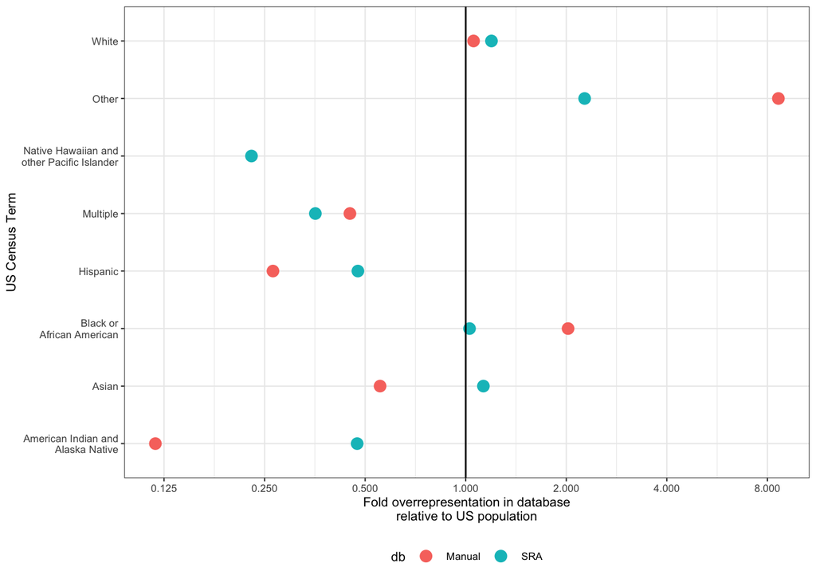

```r
ggplot(allRaceProps, aes(x = excess, y=strictestRace, color=db)) +
  geom_point(size = 3) +
  # scale_x_continuous(trans='log2', breaks = trans_breaks("log2", function(x) 2^x), labels = trans_format("log2", math_format(2^.x))) +
  scale_x_continuous(trans='log2', breaks = trans_breaks("log2", function(x) 2^x)) +
  geom_vline(xintercept = 1) +
  # annotation_logticks(sides="b") +
  xlab("Fold overrepresentation in database\nrelative to US population") +
  ylab("US Census Term") +
  theme_bw(base_size = 8) +
  theme(legend.title.align = 1, legend.direction = "horizontal", legend.background=element_blank(), legend.position="bottom")
```

```r
ggsave("us_census_overrepresentation.pdf", width = 3, height = 5)
ggsave("us_census_overrepresentation.png", width = 3, height = 5)
```

Much easier…

And now, remaking the plot of samples by study across SRA and dbGaP

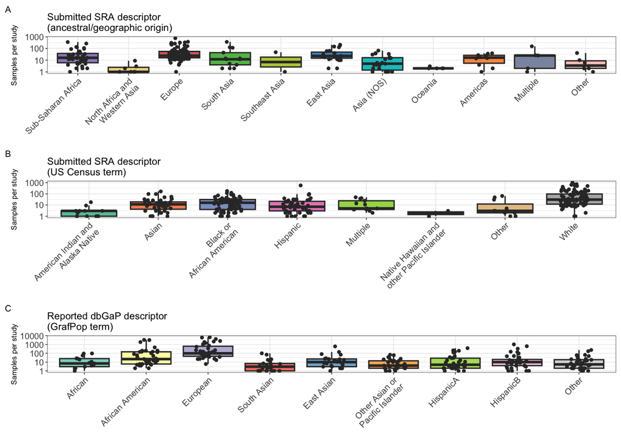

```r
sampleGeography <- allSRAFinal %>% count(SRA.Study, strictestGeography) %>% drop_na(strictestGeography)
sampleRace <- allSRAFinal %>% count(SRA.Study, strictestRace) %>% drop_na(strictestRace)
meltSampleGeography <- melt(sampleGeography)
meltSampleRace <- melt(sampleRace)
geobyStudy <- ggplot(meltSampleGeography, aes(x = strictestGeography, y=value,fill=strictestGeography)) +
  geom_boxplot(width=0.8, outlier.shape = NA) +
  geom_jitter(size=0.8, width=0.2, color="#333333") +
  ggtitle("Submitted SRA descriptor\n(ancestral/geographic origin)") +
  xlab("") +
  ylab("Samples per study") +
  scale_y_continuous(trans='log10') +
  scale_fill_geography() +
  theme(axis.text.x = element_text(angle = 45, hjust=1)) +
  theme(legend.position = "none")

racebyStudy <- ggplot(meltSampleRace, aes(x = strictestRace, y=value,fill=strictestRace)) +
  geom_boxplot(width=0.8, outlier.shape = NA) +
  geom_jitter(size=0.8, width=0.2, color="#333333") +
  ggtitle("Submitted SRA descriptor\n(US Census term)") +
  xlab("") +
  ylab("Samples per study") +
  scale_y_continuous(trans='log10') +
  scale_fill_race() +
  theme(axis.text.x = element_text(angle = 45, hjust=1)) +
  theme(legend.position = "none")

dbGapbyStudy <- dbGapFinal %>% filter(value > 0) %>%
  ggplot(., aes(x = variable, y=value,fill=variable)) +
  geom_boxplot(width=0.8, outlier.shape = NA) +
  geom_jitter(size=0.8, width=0.2, color="#333333") +
  ggtitle("Reported dbGaP descriptor\n(GrafPop term)") +
  xlab("") +
  ylab("Samples per study") +
  scale_y_continuous(trans='log10') +
  scale_fill_dbGap() +
  theme(axis.text.x = element_text(angle = 45, hjust=1)) +
  theme(legend.position = "none")

geobyStudy + racebyStudy + dbGapbyStudy +
  plot_layout(design = long3Design) +
  plot_annotation(tag_levels = 'A')
```

```r
ggsave("fig2_by_study_boxplot_all.pdf", width=6.5, height=8)
ggsave("fig2_by_study_boxplot_all.png", width=6.5, height=8)
```

Finally, we examine the studies only from the USA, because reviewer 2 wants to see that:

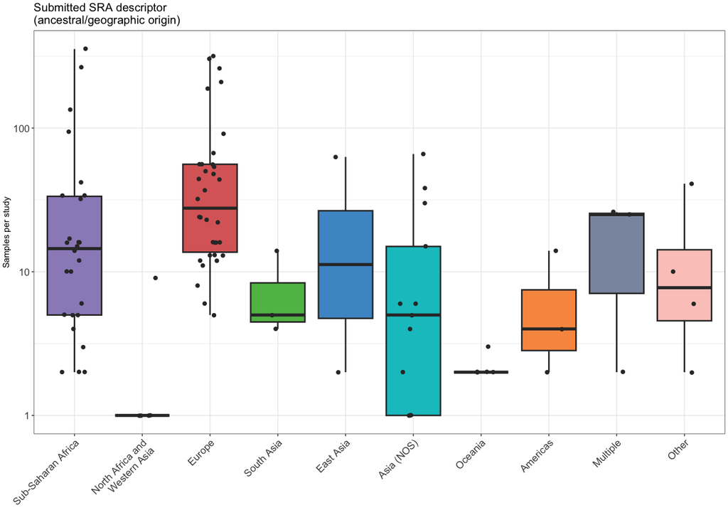

```r
allSRAUSA <- allSRAFinal %>% filter(finalCountry == "USA")

sampleGeographyUSA <- allSRAUSA %>% count(SRA.Study, strictestGeography) %>% drop_na(strictestGeography)
sampleRaceUSA <- allSRAUSA %>% count(SRA.Study, strictestRace) %>% drop_na(strictestRace)
meltSampleGeographyUSA <- melt(sampleGeographyUSA)
meltSampleRaceUSA <- melt(sampleRaceUSA)
geobyStudyUSA <- ggplot(meltSampleGeographyUSA, aes(x = strictestGeography, y=value,fill=strictestGeography)) +
  geom_boxplot(width=0.8, outlier.shape = NA) +
  geom_jitter(size=0.8, width=0.2, color="#333333") +
  ggtitle("Submitted SRA descriptor\n(ancestral/geographic origin)") +
  xlab("") +
  ylab("Samples per study") +
  scale_y_continuous(trans='log10') +
  scale_fill_geography() +
  theme(axis.text.x = element_text(angle = 45, hjust=1)) +
  theme(legend.position = "none")

racebyStudyUSA <- ggplot(meltSampleRaceUSA, aes(x = strictestRace, y=value,fill=strictestRace)) +
  geom_boxplot(width=0.8, outlier.shape = NA) +
  geom_jitter(size=0.8, width=0.2, color="#333333") +
  ggtitle("Submitted SRA descriptor\n(US Census term)") +
  xlab("") +
  ylab("Samples per study") +
  scale_y_continuous(trans='log10') +
  scale_fill_race() +
  theme(axis.text.x = element_text(angle = 45, hjust=1)) +
  theme(legend.position = "none")

geobyStudyUSA
```

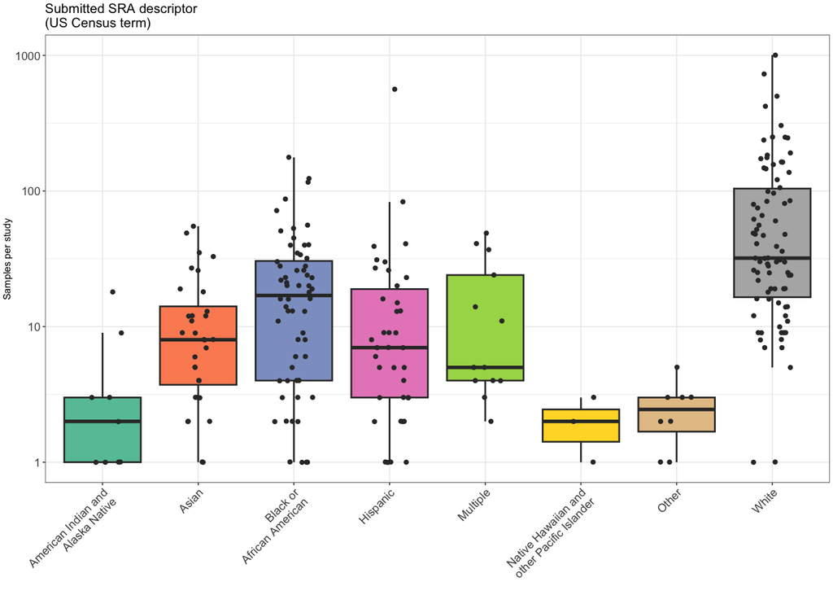

```r
racebyStudyUSA
```

```r
# Then let's do a chisq test for racial term usage between the USA and Belgium, for funsies:

contTable <- allSRAFinal %>% filter(finalCountry == "USA" | finalCountry == "Belgium") %>% drop_na(strictestRace) %>% count(finalCountry, strictestRace)

contTable2 <- pivot_wider(contTable, names_from = finalCountry, values_from = n, )
contTable2$Belgium[is.na(contTable2$Belgium)] <- 0

chisq.test(contTable2$Belgium, contTable2$USA)
```

```
##
##  Pearson's Chi-squared test
##
## data:  contTable2$Belgium and contTable2$USA
## X-squared = 40, df = 35, p-value = 0.2578
```

# Figure 3: The manual review!

Combines panels from previous versions of figs 1 and 2 into a single figure for all things manual review related.

```r
litRevGeoProp <- litRevFinal %>% drop_na(finalGeo) %>% group_by(finalGeo) %>% summarise(n = sum(individs)) %>% mutate(freq = n/sum(n))
litRevRaceProp <- litRevFinal %>% drop_na(finalRace) %>% group_by(finalRace) %>% summarise(n = sum(individs)) %>% mutate(freq = n/sum(n))

litRevGeoPlot <- ggplot(litRevGeoProp, aes(x = fct_inorder(finalGeo), y = n, fill = finalGeo)) +
  geom_bar(stat="identity") +
  ggtitle("Recorded manual descriptor\n(ancestral/geographic origin)") +
  xlab(NULL) +
  ylab(NULL) +
  coord_flip() +
  scale_fill_geography() +
  theme(axis.text.x = element_text(angle = 45, hjust=1)) +
  theme(legend.position="none") +
  theme(plot.title = element_text(hjust = 1))

litRevRacePlot <- ggplot(litRevRaceProp, aes(x = fct_rev(fct_inorder(finalRace)), y = n, fill=finalRace)) +
  geom_bar(stat="identity") +
  ggtitle("Recorded manual descriptor\n(US Census term)") +
  xlab(NULL) +
  ylab(NULL) +
  coord_flip() +
  scale_fill_race() +
  theme(axis.text.x = element_text(angle = 45, hjust=1)) +
  theme(legend.position="none") +
  theme(plot.title = element_text(hjust = 1))

# Alluvial plots and prep for the manual data only:
litRevCountry <- litRevFinal %>% drop_na(lacountry) %>% group_by(lacountry, worldRegionLA, worldBankLA, samcountry, worldRegionSample, worldBankSample, hasDescriptor) %>% summarise(value = sum(individs)) %>% mutate(db = "Manual") %>% as.data.frame()
```

[output not shown]

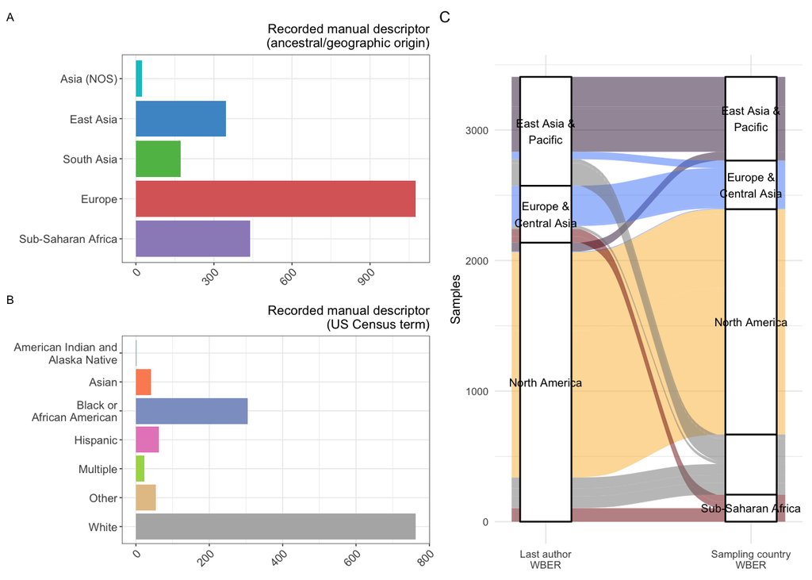

```r
# Fix a couple of names for litRev so we can do some nice stacked bar plots...
names(litRevCountry)[1:3] <- c("finalCountry", "worldRegion", "worldBank")

litRevCountry <- litRevCountry %>%
 mutate(worldBank = gsub("middle ", "middle\n", worldBank)) %>%
 mutate(worldBankSample = gsub("middle ", "middle\n", worldBankSample)) %>%
 mutate(finalCountry = if_else(grepl("USA", finalCountry), "United States", finalCountry))

manualAlluvialCountry <- litRevCountry %>% drop_na(finalCountry) %>%
 ggplot(data = ., aes(axis1 = worldRegion, axis2 = worldRegionSample, y = value)) +
   scale_x_discrete(limits = c("Last author\nWBER", "Sampling country\nWBER"), expand = c(.2, .05)) +
   geom_alluvium(aes(fill = worldRegionSample)) +
   scale_fill_wber() +
   geom_stratum(width=1/4) +
   ylab("Samples") +
   geom_text_repel(stat = "stratum", aes(label = after_stat(stratum)), direction = "y", size=0.02) +
   geom_text(stat = "stratum", aes(label = after_stat(stratum)), size=2.5) +
   theme_minimal(base_size = 8) +
   theme(legend.position = "none")

# litRevGeoPlot + litRevRacePlot + manualAlluvialCountry +
#   plot_layout(design = long3Design) +
#   plot_annotation(tag_levels = 'A')
#
# litRevGeoPlot + litRevRacePlot + manualAlluvialCountry +
#   plot_layout(design = wide3Design) +
#   plot_annotation(tag_levels = 'A')

litRevGeoPlot + litRevRacePlot + manualAlluvialCountry +
  plot_layout(design = mixed3Design) +
  plot_annotation(tag_levels = 'A')
```

```r
ggsave("all_things_manual.pdf", width=6, height=6)
ggsave("all_things_manual.png", width=6, height=6)
```

And really quickly, we want to directly compare the three datasets a bit more closely. First, how many manual review studies also had SRA metadata?

```r
litRevFinal %>% distinct(recount3) %>% nrow()
```

```
## [1] 61
```

```r
common <- intersect(unique(allSRAFinal$SRA.Study), unique(litRevFinal$recount3)) # But this is only in the final dataset...
common
```

```
## [1] "SRP043166" "SRP191569" "SRP154009"
```

```r
setdiff(unique(allSRAFinal$SRA.Study), unique(litRevFinal$recount3))
```

```
##   [1] "SRP120018" "SRP166898" "ERP007111" "SRP063355" "SRP114429" "SRP126691"
##   [7] "DRP001797" "SRP041182" "SRP096757" "SRP102952" "SRP073813" "SRP076036"
##  [13] "SRP068304" "SRP115571" "SRP135671" "ERP020576" "SRP107937" "SRP114762"
##  [19] "SRP186205" "SRP110564" "ERP116722" "SRP074739" "SRP136794" "SRP164913"
##  [25] "SRP103099" "SRP155483" "SRP181468" "SRP126861" "SRP067914" "SRP125882"
##  [31] "SRP081605" "SRP174638" "SRP122876" "ERP104698" "SRP068551" "SRP118614"
##  [37] "SRP103588" "ERP022909" "ERP001942" "SRP223239" "SRP081574" "SRP089814"
##  [43] "SRP174668" "SRP072417" "SRP070663" "SRP126583" "SRP000941" "ERP020977"
##  [49] "SRP062885" "SRP045500" "SRP066966" "ERP114122" "SRP174206" "SRP188296"
##  [55] "SRP186088" "SRP133302" "SRP133316" "SRP159625" "SRP191576" "SRP200298"
##  [61] "SRP237498" "SRP179998" "SRP237337" "SRP188874" "SRP245400" "SRP199000"
##  [67] "SRP199001" "SRP226691" "SRP116913" "SRP190479" "SRP212343" "SRP212369"
##  [73] "SRP212370" "SRP192408" "SRP258285" "ERP117085" "SRP221484" "SRP233284"
##  [79] "SRP259314" "SRP225709" "SRP266877" "SRP265899" "SRP231267" "SRP237697"
##  [85] "SRP222944" "SRP223581" "SRP223674" "SRP219483" "SRP107326" "SRP108674"
```

[output cut: 26 more lines]

```r
allSRAFinal %>% filter(SRA.Study %in% common) %>% count(SRA.Study, strictestRace)
```

```
##   SRA.Study              strictestRace  n
## 1 SRP043166                      White 12
## 2 SRP154009                       <NA> 44
## 3 SRP191569 Black or\nAfrican American  8
## 4 SRP191569                      White  8
```

```r
allSRAFinal %>% filter(SRA.Study %in% common) %>% count(SRA.Study, strictestGeography)
```

```
##   SRA.Study strictestGeography  n
## 1 SRP043166               <NA> 12
## 2 SRP154009             Europe 44
## 3 SRP191569               <NA> 16
```

```r
litRevFinal %>% filter(recount3 %in% common)
```

```
##     X  recount3     lacountry ReportedS       ReportedT individs
## 1  18 SRP043166         Spain      race       Caucasian        3
## 2  19 SRP043166         Spain      race        Hispanic        6
## 3  91 SRP154009 United States      race White/Caucasian        2
## 4 113 SRP191569 United States      race           White        8
## 5 114 SRP191569 United States      race           Black        8
##           samcountry genotypes InterpretS                InterpretT
## 1 Unreported/Unknown       Yes       race                     White
## 2 Unreported/Unknown       Yes       race                  hispanic
## 3               <NA>        No       race                     White
## 4      United States        No       race                     White
## 5      United States        No       race Black or African American
##          tempRace tempGeo                  finalRace finalGeo worldBankSample
## 1       Caucasian    <NA>                      White     <NA>            <NA>
## 2        Hispanic    <NA>                   Hispanic     <NA>            <NA>
## 3 White/Caucasian    <NA>                      White     <NA>            <NA>
## 4           White    <NA>                      White     <NA>     High income
## 5           Black    <NA> Black or\nAfrican American     <NA>     High income
##   worldBankLA worldRegionSample          worldRegionLA hasDescriptor
## 1 High income              <NA> Europe &\nCentral Asia        Racial
## 2 High income              <NA> Europe &\nCentral Asia        Racial
## 3 High income              <NA>          North America        Racial
## 4 High income     North America          North America        Racial
## 5 High income     North America          North America        Racial
```

```r
intersect(unique(allSRAClean$SRA.Study), unique(litRevFinal$recount3))
```

```
##  [1] "SRP045048" "SRP026359" "SRP002128" "SRP159081" "SRP108507" "SRP150315"
##  [7] "SRP034875" "SRP061192" "SRP090787" "SRP125110" "SRP043162" "SRP015670"
## [13] "SRP151309" "SRP066571" "SRP191514" "SRP118741" "SRP049605" "SRP217543"
## [19] "SRP102186" "SRP221482" "SRP110609" "SRP001540" "SRP178271" "SRP133573"
## [25] "SRP041538" "SRP161704" "SRP136057" "SRP056733" "SRP101959" "SRP162654"
## [31] "SRP079684" "SRP102999" "SRP187431" "SRP074274" "SRP102104" "SRP148477"
## [37] "SRP043166" "SRP158591" "SRP105047" "SRP191569" "SRP082143" "ERP004078"
## [43] "SRP221351" "SRP115408" "SRP078541" "SRP128940" "SRP076099" "SRP033725"
## [49] "SRP154009" "SRP100947" "ERP012180" "SRP114956" "SRP059035" "SRP162774"
## [55] "SRP047232" "SRP071837" "SRP043684" "SRP136469" "SRP039361" "SRP144647"
## [61] "SRP045999"
```

```r
setdiff(unique(litRevFinal$recount3), unique(allSRAClean$SRA.Study))
```

```
## character(0)
```

And then, of the studies we looked at manually, how often did we fail to get metadata for them despite it existing? This is the raw dump from the survey, so it’s messy and not worth thinking about too hard, but the individual studies are in there…

```r
rawLitRev <- read.table("20260301_recount3_RNA-seq_diversity_Form_Responses.tsv", header=T, sep="\t", fill=T, comment.char = "")

names(rawLitRev)[2] <- "SRA.Study"
noLitData <- setdiff(rawLitRev$SRA.Study, litRevFinal$recount3)

intersect(noLitData, unique(allSRAFinal$SRA.Study)) # None! Tada! We are done!
```

```
## character(0)
```